# Modelling Continuous Outcome: Linear Regression

Kamarul Imran Musa Professor (Epidemiology and Statistics)

2023-11-14

# Linear Regression - Practicals

## Short practicals

In this short practicals, we will show for linear regression model how to perform

- estimation
- inference
- prediction and
- model checking

As pre-requisites, make sure you have

- created a new project
- placed the dataset inside the project directory

Then, load the required R libraries

```r
library(tidyverse) #data wrangling and data visualization
library(haven) #read statistical data
library(here) #facilitate setting of directory location
library(broom) #tidier results
```

Then, we read the data into R.

```r
data0 <- read_dta(here('datamssm_a.dta'), .name_repair = 'unique')
glimpse(data0)
```

```
## Rows: 4,340
## Columns: 21
## $ codesub  <chr> "R-S615112", "MAA615089", "M-M616372", "MFM615361", "R-A61578…
## $ age      <dbl> 70, 20, 29, 25, 37, 43, 26, 28, 48, 20, 56, 55, 26, 39, 18, 2…
## $ hpt      <dbl+lbl> 1, 0, 0, 0, 0, 0, 0, 0, 0, 0, 1, 0, 0, 0, 0, 0, 0, 0, 0, …
## $ smoking  <dbl+lbl> 3, 1, 3, 1, 3, 3, 3, 3, 1, 3, 3, 3, 3, 3, 3, 3, 3, 3, 1, …
## $ dmdx     <dbl+lbl> 0, 0, 0, 0, 0, 0, 0, 0, 0, 0, 0, 0, 0, 0, 0, 0, 0, 0, 0, …
## $ height   <dbl> 1.54, 1.74, 1.54, 1.60, 1.44, 1.46, 1.47, 1.61, 1.68, 1.55, 1…
## $ weight   <dbl> 40.0, 54.6, 37.0, 48.4, 44.5, 45.5, 48.0, 40.0, 48.4, 41.0, 5…
## $ waist    <dbl> 76.0, 83.0, 83.0, 83.5, 85.0, 90.0, 91.0, 80.0, 82.0, 79.0, 9…
## $ hip      <dbl> 61, 62, 63, 64, 64, 64, 64, 64, 65, 66, 67, 67, 67, 67, 67, 6…
## $ msbpr    <dbl> 135.0, 105.0, 91.0, 117.0, 102.0, 124.0, 120.0, 85.0, 112.0, …
## $ mdbpr    <dbl> 80.0, 58.0, 60.0, 68.5, 78.0, 65.5, 77.0, 60.0, 74.0, 52.0, 1…
## $ hba1c    <dbl> 5.2, 5.3, 4.8, 4.8, 5.1, 5.1, 4.8, 4.9, 5.6, 4.2, 5.1, 5.3, 4…
## $ fbs      <dbl> 3.99, 4.26, 4.94, 4.60, 4.60, 4.42, 3.82, 4.40, 4.80, 3.68, 6…
## $ mogtt1h  <dbl> 7.06, 8.63, 6.26, 4.31, 9.49, 6.29, NA, 6.43, 9.23, 6.70, 8.7…
## $ mogtt2h  <dbl> 3.22, 6.49, 5.15, 3.85, 7.71, 5.65, 5.88, 4.89, 4.29, 2.59, 7…
## $ totchol  <dbl> 5.43, 5.13, 5.55, 4.01, 5.21, 6.19, 4.33, 5.84, 6.14, 6.02, 6…
## $ ftrigliz <dbl> 1.06, 1.17, 0.72, 1.12, 0.78, 1.11, 0.73, 0.79, 1.63, 0.81, 1…
## $ hdl      <dbl> 1.65, 1.59, 2.24, 1.21, 1.43, 2.18, 0.98, 1.81, 1.63, 1.47, 1…
## $ ldl      <dbl> 2.69, 2.79, 2.55, 1.83, 2.40, 2.93, 1.82, 3.43, 3.71, 2.77, 3…
## $ gender   <dbl+lbl> 0, 1, 0, 1, 0, 0, 0, 0, 1, 0, 0, 0, 0, 0, 0, 0, 0, 0, 1, …
## $ crural   <dbl+lbl> 1, 1, 1, 1, 1, 1, 1, 1, 1, 1, 1, 1, 0, 1, 0, 1, 1, 0, 1, …
```

Convert all labelled variables to factor variables and perform simple summary checking

```r
data0 <- data0 %>%
  mutate(across(where(is.labelled), as_factor))
summary(data0)
```

```
##    codesub               age         hpt                  smoking
##  Length:4340        Min.   :18.00   no :3836   still smoking  : 698
##  Class :character   1st Qu.:38.00   yes: 504   quitted smoking: 335
##  Mode  :character   Median :48.00              never smoked   :3307
##                     Mean   :47.84
##                     3rd Qu.:58.00
##                     Max.   :89.00
##
##   dmdx          height          weight           waist             hip
##  no :3870   Min.   :1.270   Min.   : 30.00   Min.   : 50.80   Min.   : 61.00
##  yes: 470   1st Qu.:1.510   1st Qu.: 53.80   1st Qu.: 77.00   1st Qu.: 91.00
##             Median :1.560   Median : 62.00   Median : 86.00   Median : 97.00
##             Mean   :1.568   Mean   : 63.75   Mean   : 86.32   Mean   : 97.88
##             3rd Qu.:1.630   3rd Qu.: 71.97   3rd Qu.: 95.00   3rd Qu.:104.00
##             Max.   :1.960   Max.   :187.80   Max.   :154.50   Max.   :160.00
##             NA's   :1       NA's   :2        NA's   :2        NA's   :2
##      msbpr           mdbpr            hba1c             fbs
##  Min.   : 68.5   Min.   : 41.50   Min.   : 0.200   Min.   : 2.500
##  1st Qu.:117.0   1st Qu.: 70.00   1st Qu.: 5.100   1st Qu.: 4.480
##  Median :130.0   Median : 77.50   Median : 5.400   Median : 5.180
##  Mean   :133.5   Mean   : 78.47   Mean   : 5.805   Mean   : 5.734
##  3rd Qu.:146.5   3rd Qu.: 86.00   3rd Qu.: 5.800   3rd Qu.: 6.020
##  Max.   :237.0   Max.   :128.50   Max.   :15.000   Max.   :28.010
##                                   NA's   :70       NA's   :248
##     mogtt1h          mogtt2h          totchol          ftrigliz
##  Min.   : 0.160   Min.   : 0.160   Min.   : 0.180   Min.   : 0.110
##  1st Qu.: 6.540   1st Qu.: 5.150   1st Qu.: 4.970   1st Qu.: 0.930
##  Median : 8.590   Median : 6.600   Median : 5.700   Median : 1.260
##  Mean   : 9.106   Mean   : 7.343   Mean   : 5.792   Mean   : 1.534
##  3rd Qu.:10.840   3rd Qu.: 8.410   3rd Qu.: 6.530   3rd Qu.: 1.770
##  Max.   :41.500   Max.   :37.370   Max.   :23.140   Max.   :12.660
##  NA's   :604      NA's   :608      NA's   :54       NA's   :53
##       hdl             ldl            gender       crural
##  Min.   :0.080   Min.   : 0.140   female:2817   urban:2218
##  1st Qu.:1.110   1st Qu.: 2.790   male  :1523   rural:2122
##  Median :1.320   Median : 3.460
##  Mean   :1.345   Mean   : 3.549
##  3rd Qu.:1.540   3rd Qu.: 4.245
##  Max.   :4.430   Max.   :10.560
##  NA's   :52      NA's   :53
```

### Estimation

This is to estimate a constant only model (model with only the dependent variable).

```r
mod0 <- lm(hba1c ~ 1, data = data0)
summary(mod0)
```

```
##
## Call:
## lm(formula = hba1c ~ 1, data = data0)
##
## Residuals:
##     Min      1Q  Median      3Q     Max
## -5.6052 -0.7052 -0.4052 -0.0052  9.1948
##
## Coefficients:
##             Estimate Std. Error t value Pr(>|t|)
## (Intercept)  5.80520    0.02217   261.9   <2e-16 ***
## ---
## Signif. codes:  0 '***' 0.001 '**' 0.01 '*' 0.05 '.' 0.1 ' ' 1
##
## Residual standard error: 1.448 on 4269 degrees of freedom
##   (70 observations deleted due to missingness)
```

This is a univariable model, where the model has

- one dependent variable (hba1c)
- only one covariate or predictor or independent variable

```r
modldl <- lm(hba1c ~ ldl, data = data0)
summary(modldl)
```

```
##
## Call:
## lm(formula = hba1c ~ ldl, data = data0)
##
## Residuals:
##     Min      1Q  Median      3Q     Max
## -5.6901 -0.6667 -0.3727  0.0104  8.8945
##
## Coefficients:
##             Estimate Std. Error t value Pr(>|t|)
## (Intercept)  5.08897    0.07246   70.23   <2e-16 ***
## ldl          0.20130    0.01946   10.35   <2e-16 ***
## ---
## Signif. codes:  0 '***' 0.001 '**' 0.01 '*' 0.05 '.' 0.1 ' ' 1
##
## Residual standard error: 1.428 on 4263 degrees of freedom
##   (75 observations deleted due to missingness)
## Multiple R-squared:  0.0245, Adjusted R-squared:  0.02427
## F-statistic: 107.1 on 1 and 4263 DF,  p-value: < 2.2e-16
```

Multivariable model with no interaction

Now, we let’s estimate a multivariable model, that’s a model with

- One dependent variable (hba1c)
- two or more covariates.

In this example, we will use ldl and gender as covariates

```r
modldl.gender <- lm(hba1c ~ ldl + gender, data = data0)
summary(modldl.gender)
```

```
##
## Call:
## lm(formula = hba1c ~ ldl + gender, data = data0)
##
## Residuals:
##     Min      1Q  Median      3Q     Max
## -5.7168 -0.6644 -0.3759  0.0068  8.9088
##
## Coefficients:
##             Estimate Std. Error t value Pr(>|t|)
## (Intercept)  5.07444    0.07426  68.332   <2e-16 ***
## ldl          0.20134    0.01946  10.349   <2e-16 ***
## gendermale   0.04100    0.04583   0.895    0.371
## ---
## Signif. codes:  0 '***' 0.001 '**' 0.01 '*' 0.05 '.' 0.1 ' ' 1
##
## Residual standard error: 1.428 on 4262 degrees of freedom
##   (75 observations deleted due to missingness)
## Multiple R-squared:  0.02468,    Adjusted R-squared:  0.02422
## F-statistic: 53.92 on 2 and 4262 DF,  p-value: < 2.2e-16
```

Multivariable with interaction

Now, we will add a new covariate (an interaction term) which is the product of two covariates

- dependent variable (hba1c)
- covariates ldl and gender (`ldl + gender`)
- interaction covariate: (`ldl*gender`)

```r
modldl.gender.ia <- lm(hba1c ~ ldl + gender + ldl:gender,
                       data = data0)
summary(modldl.gender.ia)
```

```
##
## Call:
## lm(formula = hba1c ~ ldl + gender + ldl:gender, data = data0)
##
## Residuals:
##     Min      1Q  Median      3Q     Max
## -5.7152 -0.6641 -0.3759  0.0076  8.9058
##
## Coefficients:
##                 Estimate Std. Error t value Pr(>|t|)
## (Intercept)     5.067460   0.089424  56.668   <2e-16 ***
## ldl             0.203310   0.023982   8.478   <2e-16 ***
## gendermale      0.061427   0.152657   0.402    0.687
## ldl:gendermale -0.005754   0.041028  -0.140    0.888
## ---
## Signif. codes:  0 '***' 0.001 '**' 0.01 '*' 0.05 '.' 0.1 ' ' 1
##
## Residual standard error: 1.428 on 4261 degrees of freedom
##   (75 observations deleted due to missingness)
## Multiple R-squared:  0.02468,    Adjusted R-squared:  0.024
## F-statistic: 35.95 on 3 and 4261 DF,  p-value: < 2.2e-16
```

### Inference

For inference, we will calculate the $95\%$ for the $\hat{\beta}$ . We can produce nicer results with `broom::tidy()`

```r
tidy(modldl, conf.int = TRUE)
```

| term | estimate | std.error | statistic | p.value | conf.low | conf.high |
| --- | --- | --- | --- | --- | --- | --- |
| (Intercept) | 5.0889735 | 0.07246311 | 70.22847 | 0.000000e+00 | 4.9469081 | 5.2310390 |
| ldl | 0.2013003 | 0.01945564 | 10.34663 | 8.500251e-25 | 0.1631571 | 0.2394434 |

```r
tidy(modldl.gender, conf.int = TRUE)
```

| term | estimate | std.error | statistic | p.value | conf.low | conf.high |
| --- | --- | --- | --- | --- | --- | --- |
| (Intercept) | 5.07444499 | 0.07426175 | 68.3318834 | 0.000000e+00 | 4.92885330 | 5.2200367 |
| ldl | 0.20134400 | 0.01945616 | 10.3485992 | 8.332335e-25 | 0.16319979 | 0.2394882 |
| gendermale | 0.04100446 | 0.04582792 | 0.8947484 | 3.709721e-01 | -0.04884214 | 0.1308511 |

```r
tidy(modldl.gender.ia)
```

| term | estimate | std.error | statistic | p.value |
| --- | --- | --- | --- | --- |
| (Intercept) | 5.067459669 | 0.08942402 | 56.6677662 | 0.000000e+00 |
| ldl | 0.203310036 | 0.02398186 | 8.4776579 | 3.126538e-17 |
| gendermale | 0.061427100 | 0.15265655 | 0.4023876 | 6.874190e-01 |
| ldl:gendermale | -0.005754316 | 0.04102834 | -0.1402522 | 8.884674e-01 |

### Prediction

Now, we can get the fitted values for hba1c that’s the average values of the dependent variable given the covariates values

```r
augment(modldl) %>% head()
```

| .rownames | hba1c | ldl | .fitted | .resid | .hat | .sigma | .cooksd | .std.resid |
| --- | --- | --- | --- | --- | --- | --- | --- | --- |
| 1 | 5.2 | 2.69 | 5.630471 | -0.4304712 | 0.0003720541 | 1.428124 | 1.691797e-05 | -0.3015125 |
| 2 | 5.3 | 2.79 | 5.650601 | -0.3506012 | 0.0003419476 | 1.428129 | 1.031369e-05 | -0.2455659 |
| 3 | 4.8 | 2.55 | 5.602289 | -0.8022892 | 0.0004204405 | 1.428086 | 6.641442e-05 | -0.5619564 |
| 4 | 4.8 | 1.83 | 5.457353 | -0.6573530 | 0.0007842277 | 1.428104 | 8.322459e-05 | -0.4605209 |
| 5 | 5.1 | 2.40 | 5.572094 | -0.4720941 | 0.0004803580 | 1.428121 | 2.627667e-05 | -0.3306841 |
| 6 | 5.1 | 2.93 | 5.678783 | -0.5787833 | 0.0003060356 | 1.428112 | 2.515362e-05 | -0.4053805 |

```r
augment(modldl.gender.ia) %>% tail()
```

| .rownames | hba1c | ldl | gender | .fitted | .resid | .hat | .sigma | .cooksd | .std.resid |
| --- | --- | --- | --- | --- | --- | --- | --- | --- | --- |
| 4335 | 5.8 | 3.92 | female | 5.864435 | -0.06443501 | 0.0003989901 | 1.428337 | 2.032044e-07 | -0.04512621 |
| 4336 | 7.9 | 4.53 | male | 6.023814 | 1.87618582 | 0.0011938196 | 1.428047 | 5.163076e-04 | 1.31448460 |
| 4337 | 5.3 | 3.00 | male | 5.721554 | -0.42155393 | 0.0008315087 | 1.428322 | 1.814162e-05 | -0.29529361 |
| 4338 | 6.0 | 4.24 | female | 5.929494 | 0.07050578 | 0.0004940944 | 1.428337 | 3.013486e-07 | 0.04938014 |
| 4339 | 9.5 | 4.25 | female | 5.931527 | 3.56847268 | 0.0004979969 | 1.427290 | 7.780448e-04 | 2.49925636 |
| 4340 | 10.2 | 2.54 | male | 5.630678 | 4.56932170 | 0.0012199350 | 1.426618 | 3.129543e-03 | 3.20137881 |

### Model checking

Linear regression requires linear model assumptions. Some important assumptions are

1. Linearity of residuals
2. Residuals are normally distributed
3. Equal variance of residuals
4. Independence observations

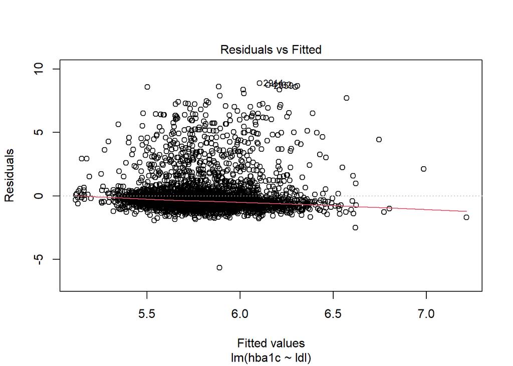

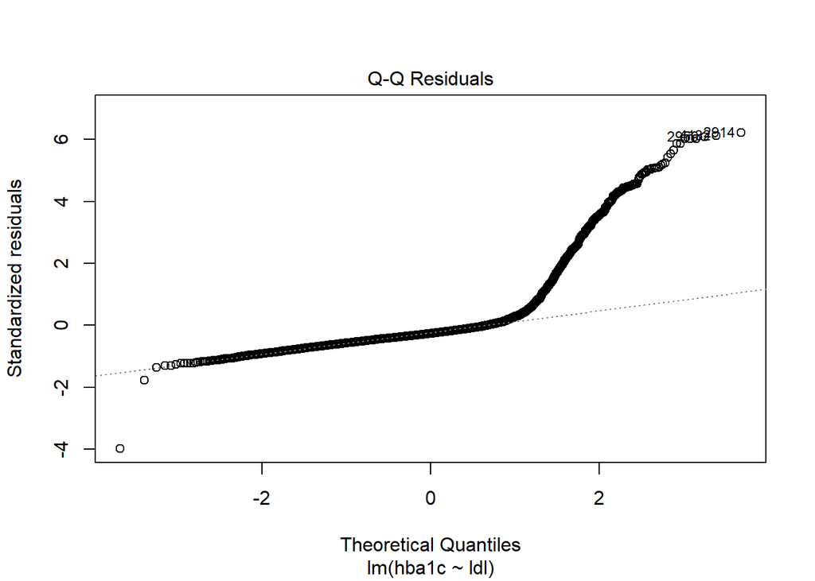

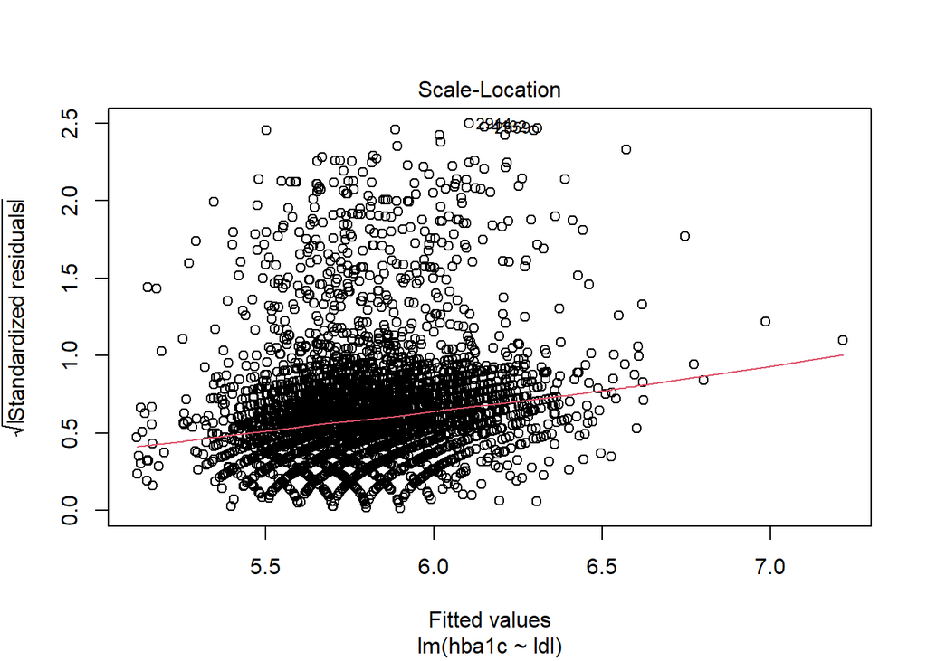

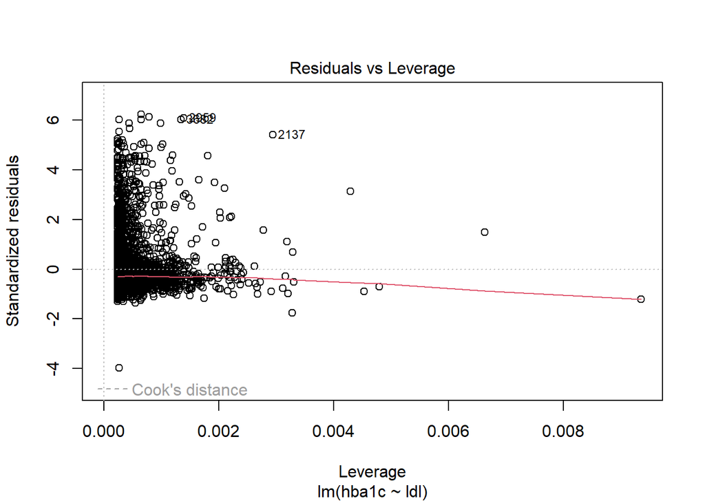

```r
plot(modldl)
```

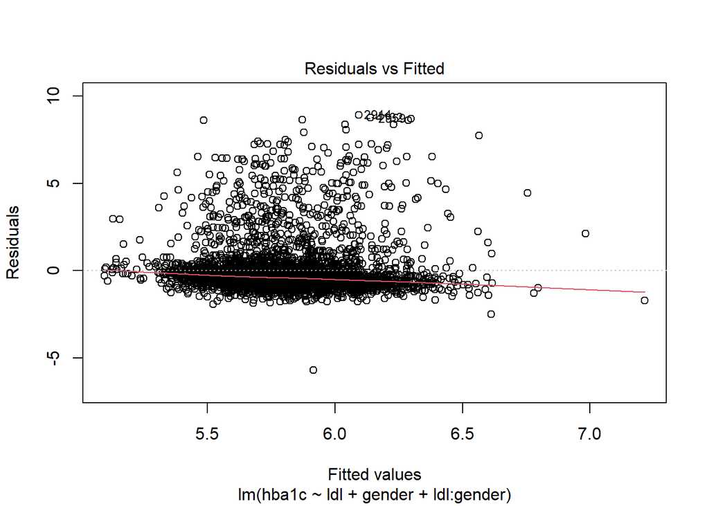

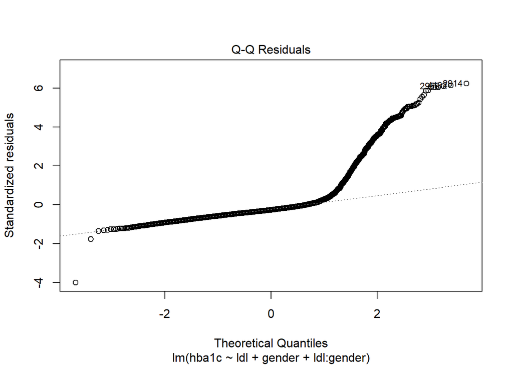

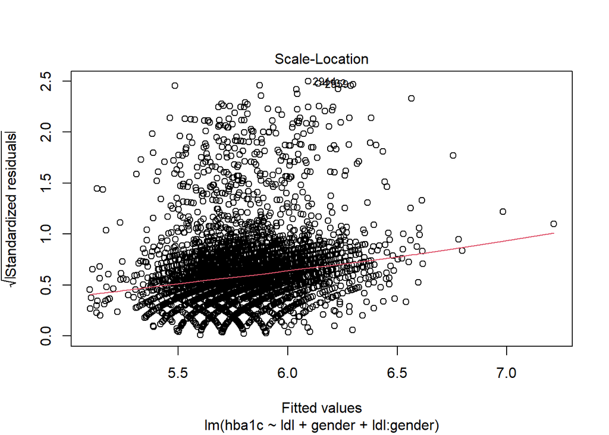

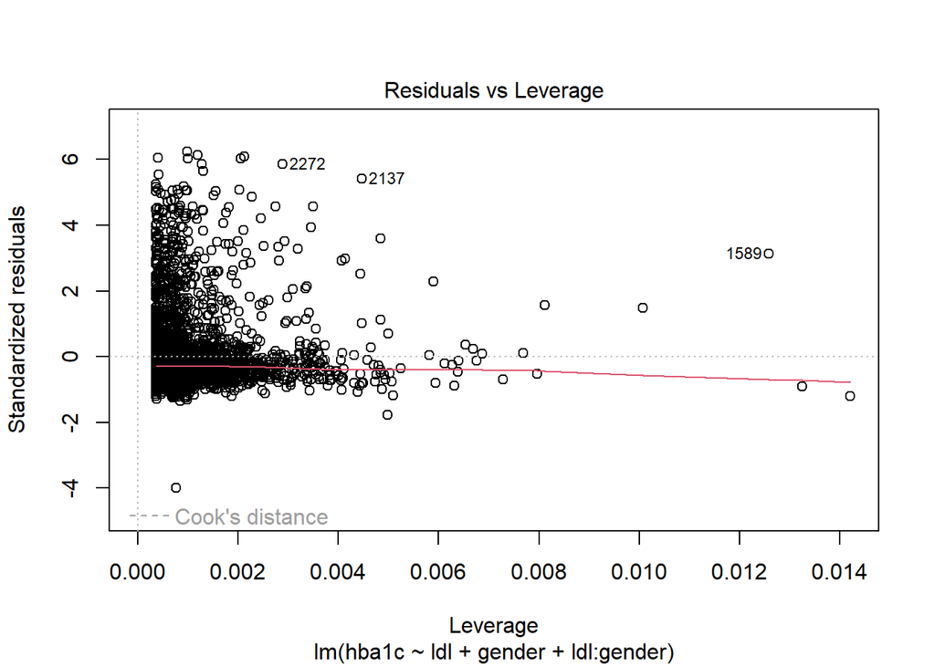

```r
plot(modldl.gender.ia)
```

What do you think of the plots?

Somethings are not right

- distribution of residuals do not look random
- possible outliers

However, the linearity maybe acceptable.

We need to do further treatment to improve our model. Some treatments include

- transformation of variables
- using more complex model
- removing the outliers or influential observations

## Long practicals

### Preparation

Set a new project in RStudio (recommended) or set a working directory. To set the new project, click

File -> New Project -> New Directory -> New Project

You need to know the file path. It is treated differently in Windows OS, Linux OS and Mac OD.

In the project, you should store your dataset and your R codes (with or without folders) inside the folder of the project directory. The directory will later save the objects and outputs such as plots.

### Load R packages

You can load R packages that you want to use for the analysis. In this project we load

1. **tidyverse** - for data wrangling and plots
2. **haven** - to read data
3. **gtsummary** - to summarize data
4. **corrplot**- to make plot for correlation
5. **knitr** - to make nice table
6. **broom** - to create nice outputs
7. **MASS** - to do variable selection
8. **tidyr** - to use `drop_na`

```r
library(tidyverse)
library(gtsummary)
```

```r
library(corrplot)
library(broom)
library(tidyr)
```

### Read data

To read `.csv`, `.txt` files, you can use **base** package. But to read statistical data from SPSS (`.sav`), Stata (`.dta`) or spreadsheet such `.xlsx` file you need user-contributed packages such as **haven**, **foreign**, **readr** or **readxl**.

Please note that, **haven** can read up to the latest STATA format while **foreign** reads until version 12.

```r
data1 <- read_dta(here('datamssm_a.dta'))
```

### Describe data

```r
summary(data1)
```

```
##    codesub               age             hpt            smoking
##  Length:4340        Min.   :18.00   Min.   :0.0000   Min.   :1.000
##  Class :character   1st Qu.:38.00   1st Qu.:0.0000   1st Qu.:3.000
##  Mode  :character   Median :48.00   Median :0.0000   Median :3.000
##                     Mean   :47.84   Mean   :0.1161   Mean   :2.601
##                     3rd Qu.:58.00   3rd Qu.:0.0000   3rd Qu.:3.000
##                     Max.   :89.00   Max.   :1.0000   Max.   :3.000
##
##       dmdx            height          weight           waist
##  Min.   :0.0000   Min.   :1.270   Min.   : 30.00   Min.   : 50.80
##  1st Qu.:0.0000   1st Qu.:1.510   1st Qu.: 53.80   1st Qu.: 77.00
##  Median :0.0000   Median :1.560   Median : 62.00   Median : 86.00
##  Mean   :0.1083   Mean   :1.568   Mean   : 63.75   Mean   : 86.32
##  3rd Qu.:0.0000   3rd Qu.:1.630   3rd Qu.: 71.97   3rd Qu.: 95.00
##  Max.   :1.0000   Max.   :1.960   Max.   :187.80   Max.   :154.50
##                   NA's   :1       NA's   :2        NA's   :2
##       hip             msbpr           mdbpr            hba1c
##  Min.   : 61.00   Min.   : 68.5   Min.   : 41.50   Min.   : 0.200
##  1st Qu.: 91.00   1st Qu.:117.0   1st Qu.: 70.00   1st Qu.: 5.100
##  Median : 97.00   Median :130.0   Median : 77.50   Median : 5.400
##  Mean   : 97.88   Mean   :133.5   Mean   : 78.47   Mean   : 5.805
##  3rd Qu.:104.00   3rd Qu.:146.5   3rd Qu.: 86.00   3rd Qu.: 5.800
##  Max.   :160.00   Max.   :237.0   Max.   :128.50   Max.   :15.000
##  NA's   :2                                         NA's   :70
##       fbs            mogtt1h          mogtt2h          totchol
##  Min.   : 2.500   Min.   : 0.160   Min.   : 0.160   Min.   : 0.180
##  1st Qu.: 4.480   1st Qu.: 6.540   1st Qu.: 5.150   1st Qu.: 4.970
##  Median : 5.180   Median : 8.590   Median : 6.600   Median : 5.700
##  Mean   : 5.734   Mean   : 9.106   Mean   : 7.343   Mean   : 5.792
##  3rd Qu.: 6.020   3rd Qu.:10.840   3rd Qu.: 8.410   3rd Qu.: 6.530
##  Max.   :28.010   Max.   :41.500   Max.   :37.370   Max.   :23.140
##  NA's   :248      NA's   :604      NA's   :608      NA's   :54
##     ftrigliz           hdl             ldl             gender
##  Min.   : 0.110   Min.   :0.080   Min.   : 0.140   Min.   :0.0000
##  1st Qu.: 0.930   1st Qu.:1.110   1st Qu.: 2.790   1st Qu.:0.0000
##  Median : 1.260   Median :1.320   Median : 3.460   Median :0.0000
##  Mean   : 1.534   Mean   :1.345   Mean   : 3.549   Mean   :0.3509
##  3rd Qu.: 1.770   3rd Qu.:1.540   3rd Qu.: 4.245   3rd Qu.:1.0000
##  Max.   :12.660   Max.   :4.430   Max.   :10.560   Max.   :1.0000
##  NA's   :53       NA's   :52      NA's   :53
##      crural
##  Min.   :0.0000
##  1st Qu.:0.0000
##  Median :0.0000
##  Mean   :0.4889
##  3rd Qu.:1.0000
##  Max.   :1.0000
##
```

Convert labelled variables to factor variables

```r
data1 <-
  data1 %>%
  mutate(across(where(is.labelled), as_factor))
summary(data1)
```

```
##    codesub               age         hpt                  smoking
##  Length:4340        Min.   :18.00   no :3836   still smoking  : 698
##  Class :character   1st Qu.:38.00   yes: 504   quitted smoking: 335
##  Mode  :character   Median :48.00              never smoked   :3307
##                     Mean   :47.84
##                     3rd Qu.:58.00
##                     Max.   :89.00
##
##   dmdx          height          weight           waist             hip
##  no :3870   Min.   :1.270   Min.   : 30.00   Min.   : 50.80   Min.   : 61.00
##  yes: 470   1st Qu.:1.510   1st Qu.: 53.80   1st Qu.: 77.00   1st Qu.: 91.00
##             Median :1.560   Median : 62.00   Median : 86.00   Median : 97.00
##             Mean   :1.568   Mean   : 63.75   Mean   : 86.32   Mean   : 97.88
##             3rd Qu.:1.630   3rd Qu.: 71.97   3rd Qu.: 95.00   3rd Qu.:104.00
##             Max.   :1.960   Max.   :187.80   Max.   :154.50   Max.   :160.00
##             NA's   :1       NA's   :2        NA's   :2        NA's   :2
##      msbpr           mdbpr            hba1c             fbs
##  Min.   : 68.5   Min.   : 41.50   Min.   : 0.200   Min.   : 2.500
##  1st Qu.:117.0   1st Qu.: 70.00   1st Qu.: 5.100   1st Qu.: 4.480
##  Median :130.0   Median : 77.50   Median : 5.400   Median : 5.180
##  Mean   :133.5   Mean   : 78.47   Mean   : 5.805   Mean   : 5.734
##  3rd Qu.:146.5   3rd Qu.: 86.00   3rd Qu.: 5.800   3rd Qu.: 6.020
##  Max.   :237.0   Max.   :128.50   Max.   :15.000   Max.   :28.010
##                                   NA's   :70       NA's   :248
##     mogtt1h          mogtt2h          totchol          ftrigliz
##  Min.   : 0.160   Min.   : 0.160   Min.   : 0.180   Min.   : 0.110
##  1st Qu.: 6.540   1st Qu.: 5.150   1st Qu.: 4.970   1st Qu.: 0.930
##  Median : 8.590   Median : 6.600   Median : 5.700   Median : 1.260
##  Mean   : 9.106   Mean   : 7.343   Mean   : 5.792   Mean   : 1.534
##  3rd Qu.:10.840   3rd Qu.: 8.410   3rd Qu.: 6.530   3rd Qu.: 1.770
##  Max.   :41.500   Max.   :37.370   Max.   :23.140   Max.   :12.660
##  NA's   :604      NA's   :608      NA's   :54       NA's   :53
##       hdl             ldl            gender       crural
##  Min.   :0.080   Min.   : 0.140   female:2817   urban:2218
##  1st Qu.:1.110   1st Qu.: 2.790   male  :1523   rural:2122
##  Median :1.320   Median : 3.460
##  Mean   :1.345   Mean   : 3.549
##  3rd Qu.:1.540   3rd Qu.: 4.245
##  Max.   :4.430   Max.   :10.560
##  NA's   :52      NA's   :53
```

Or package **gtsummary**

```r
data1 %>%
  select(-codesub) %>%
  tbl_summary(
    statistic = list(all_continuous() ~ "{mean} ({sd})")
  )
```

| **Characteristic** | **N = 4,340**<sup>1</sup> |
| --- | --- |
| reported age (years) | 48 (15) |
| hypertension (history) | 504 (12%) |
| smoking status |  |
| still smoking | 698 (16%) |
| quitted smoking | 335 (7.7%) |
| never smoked | 3,307 (76%) |
| ever been diagnosed with diabetes mellitus? | 470 (11%) |
| height (meter) | 1.57 (0.09) |
| Unknown | 1 |
| weight (kg) | 64 (14) |
| Unknown | 2 |
| waist circum (cm) | 86 (13) |
| Unknown | 2 |
| hip circum (cm) | 98 (11) |
| Unknown | 2 |
| mean SBP for right arm (mmHG) | 134 (23) |
| mean DBP for right arm (mmHG) | 78 (12) |
| mmol/l | 5.81 (1.45) |
| Unknown | 70 |
| fasting blood sugar (mmol/l) | 5.73 (2.55) |
| Unknown | 248 |
| MOGTT 1 hour post (mmol/l) | 9.1 (3.9) |
| Unknown | 604 |
| MOGTT 2 hour post (mmol/l) | 7.3 (3.7) |
| Unknown | 608 |
| total cholesterol (mmol/l) | 5.79 (1.28) |
| Unknown | 54 |
| fasting Tg (mmol/l) | 1.53 (1.05) |
| Unknown | 53 |
| high-density lipoprotein (mmol/l) | 1.35 (0.36) |
| Unknown | 52 |
| low-density lipoprotein (mmol/l) | 3.55 (1.12) |
| Unknown | 53 |
| gender |  |
| female | 2,817 (65%) |
| male | 1,523 (35%) |
| rural=1 urban=0 |  |
| urban | 2,218 (51%) |
| rural | 2,122 (49%) |

<sup>1</sup> Mean (SD); n (%)

### Explore and wrangle data

Perform plots, to look for

1. outliers
2. range of data
3. missing data
4. error in data entry
5. wrong groupings
6. distribution of data

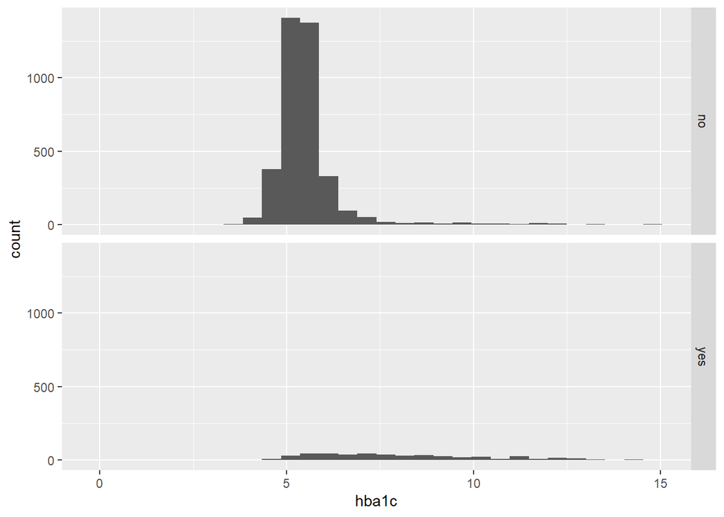

```r
ggplot(data1, aes(hba1c)) +
  geom_histogram() +
  facet_grid(dmdx~.)
```

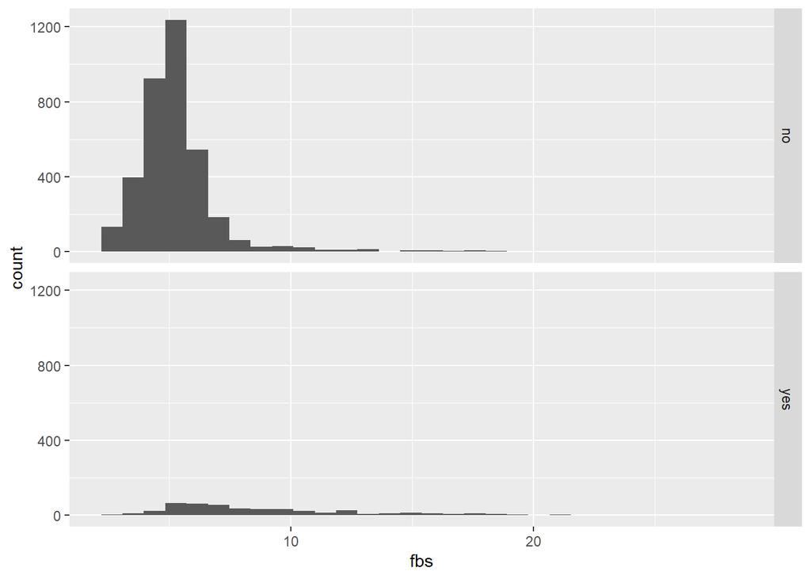

```r
ggplot(data1, aes(fbs)) +
  geom_histogram() +
  facet_grid(dmdx~.)
```

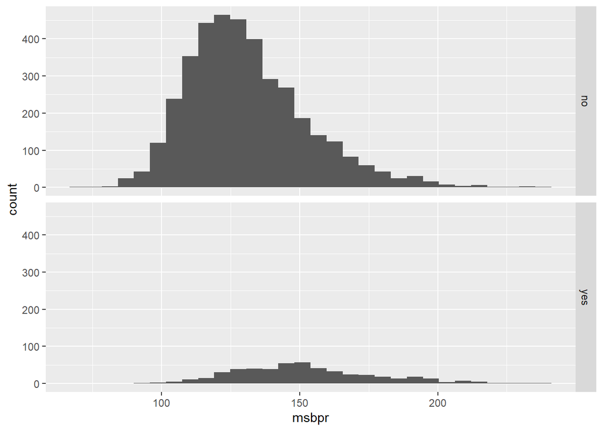

```r
ggplot(data1, aes(msbpr)) +
  geom_histogram() +
  facet_grid(hpt~.)
```

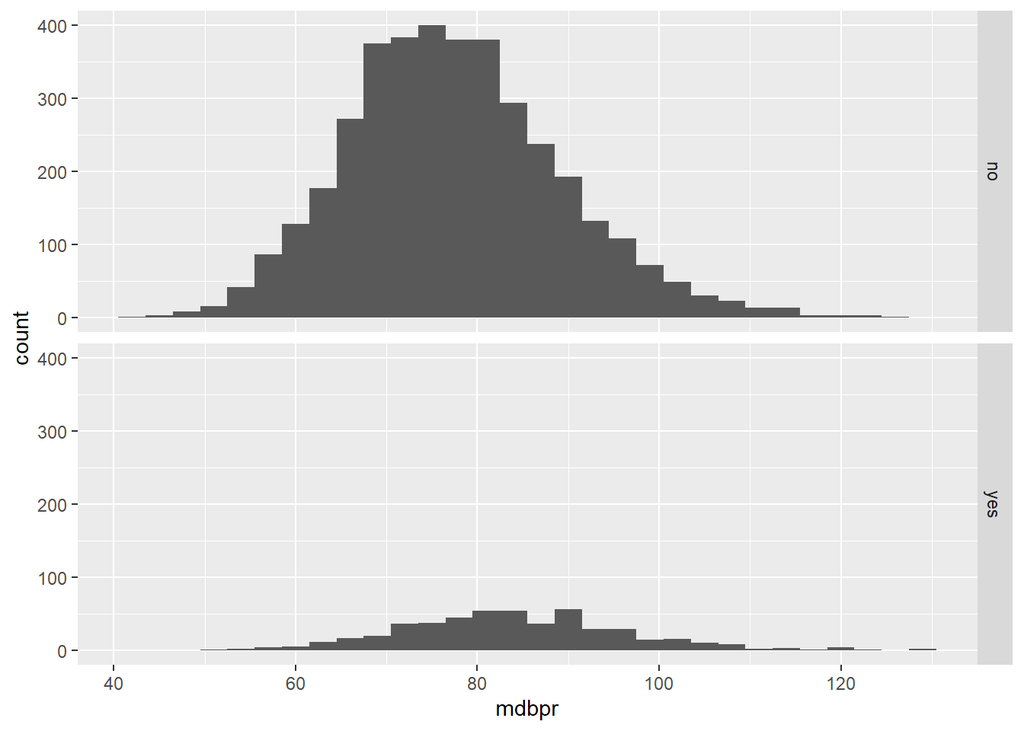

```r
ggplot(data1, aes(mdbpr)) +
  geom_histogram() +
  facet_grid(hpt~.)
```

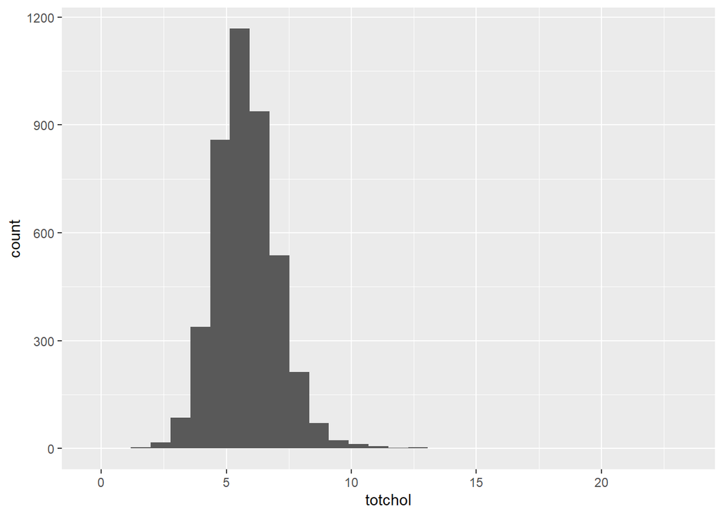

```r
ggplot(data1, aes(totchol)) +
  geom_histogram()
```

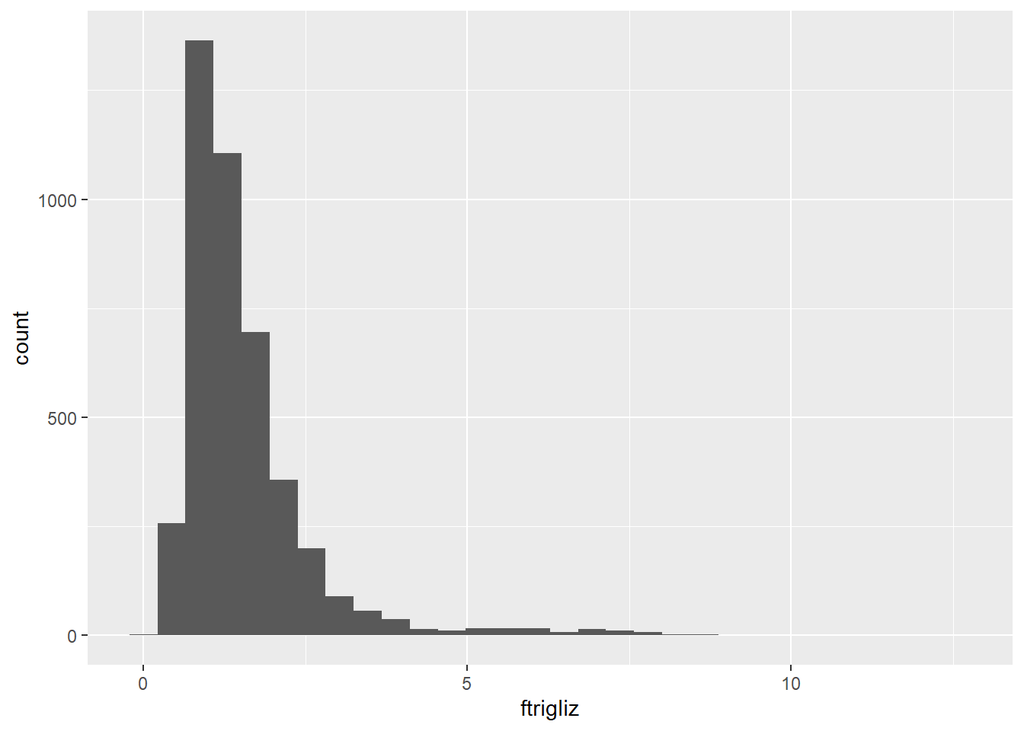

```r
ggplot(data1, aes(ftrigliz)) +
  geom_histogram()
```

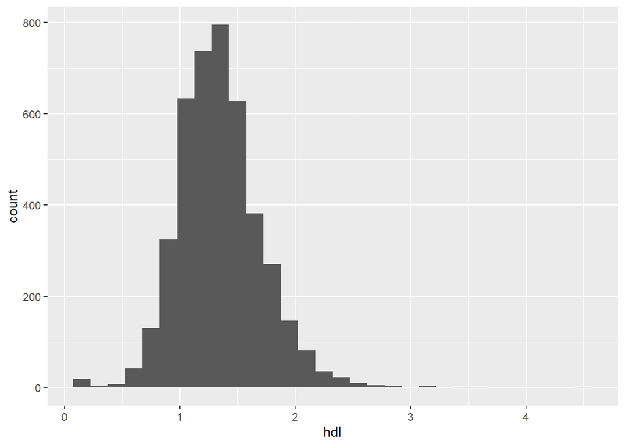

```r
ggplot(data1, aes(hdl)) +
  geom_histogram()
```

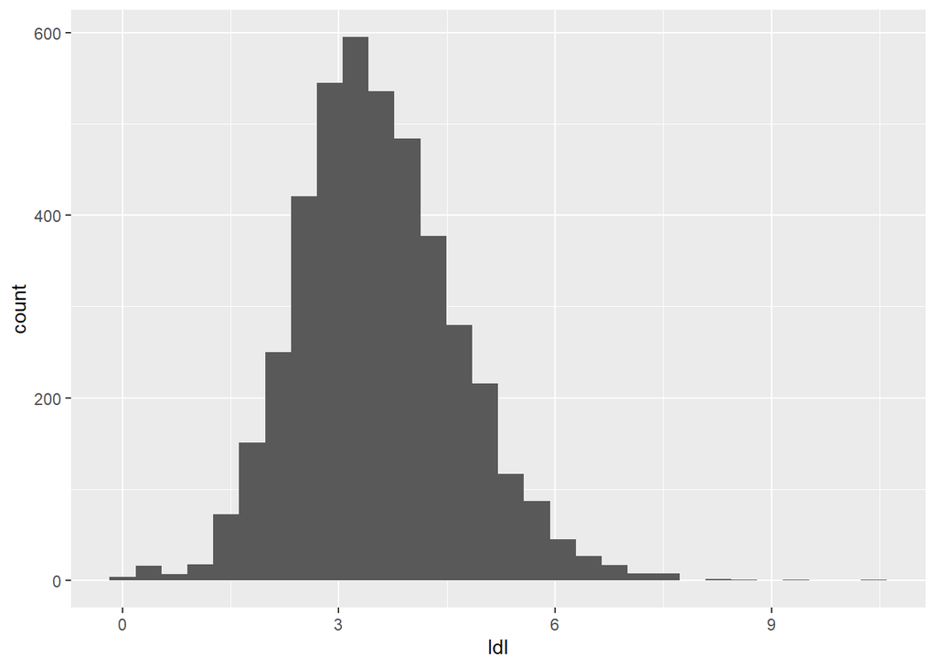

```r
ggplot(data1, aes(ldl)) +
  geom_histogram()
```

We may want to

```r
data2 <-
  data1 %>%
  filter(hba1c > 2.5, ldl > 0.5, totchol >=2.0, ftrigliz < 8, mdbpr >=40) %>%
  mutate(bmi = weight/(height^2)) %>%
  mutate(overweight = if_else(bmi >=25.0,'overwt','not_overwt'))
```

Possible high correlations between numerical variables. Any correlations bigger than 0.7?

To do that:

1. We create a new dataset with only numerical variables
2. perform correlations
3. plot correlogram

```r
data3 <-
  data2 %>%
  select(where(is.numeric))
```

The results of correlation matrix

```r
cor.data2 <-
  cor(data3,
      use = "complete.obs",
      method = "pearson")
head(round(cor.data2,2))
```

```
##          age height weight waist  hip msbpr mdbpr hba1c   fbs mogtt1h mogtt2h
## age     1.00  -0.21  -0.08  0.12 0.00  0.46  0.23  0.15  0.16    0.27    0.20
## height -0.21   1.00   0.41  0.15 0.11 -0.06  0.01 -0.04 -0.04   -0.11   -0.14
## weight -0.08   0.41   1.00  0.80 0.80  0.18  0.27  0.17  0.12    0.13    0.14
## waist   0.12   0.15   0.80  1.00 0.61  0.27  0.29  0.23  0.16    0.20    0.21
## hip     0.00   0.11   0.80  0.61 1.00  0.16  0.23  0.15  0.12    0.15    0.18
## msbpr   0.46  -0.06   0.18  0.27 0.16  1.00  0.73  0.14  0.16    0.26    0.21
##        totchol ftrigliz   hdl   ldl   bmi
## age       0.31     0.13  0.16  0.26  0.02
## height   -0.07     0.06 -0.19 -0.06 -0.09
## weight    0.04     0.21 -0.23  0.10  0.87
## waist     0.11     0.22 -0.21  0.13  0.79
## hip       0.08     0.17 -0.13  0.14  0.82
## msbpr     0.22     0.19  0.01  0.20  0.22
```

variables weight, hip, waist, might produce co-linearity problem.

This is the correlogram:

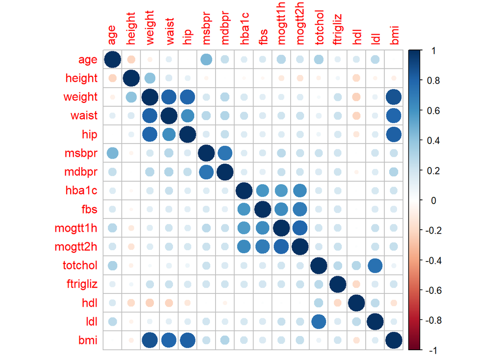

```r
corrplot(cor.data2,
         method = "circle")
```

### Perform linear regression models

#### Univariable model

Model with one dependent variable (hba1c) and one covariate (age). From this model, we can estimate the average value of hba1c conditional on age.

```r
mod.age <- lm(hba1c ~ age, data = data2)
summary(mod.age)
```

```
##
## Call:
## lm(formula = hba1c ~ age, data = data2)
##
## Residuals:
##     Min      1Q  Median      3Q     Max
## -2.2149 -0.6395 -0.3429  0.0015  9.4145
##
## Coefficients:
##             Estimate Std. Error t value Pr(>|t|)
## (Intercept) 4.857860   0.074463   65.24   <2e-16 ***
## age         0.019667   0.001491   13.19   <2e-16 ***
## ---
## Signif. codes:  0 '***' 0.001 '**' 0.01 '*' 0.05 '.' 0.1 ' ' 1
##
## Residual standard error: 1.405 on 4223 degrees of freedom
## Multiple R-squared:  0.03959,    Adjusted R-squared:  0.03936
## F-statistic: 174.1 on 1 and 4223 DF,  p-value: < 2.2e-16
```

Let us create a better table

```r
tidy(mod.age, conf.int = TRUE)
```

| term | estimate | std.error | statistic | p.value | conf.low | conf.high |
| --- | --- | --- | --- | --- | --- | --- |
| (Intercept) | 4.85786048 | 0.074462856 | 65.23871 | 0.000000e+00 | 4.71187412 | 5.00384683 |
| age | 0.01966698 | 0.001490564 | 13.19432 | 5.534972e-39 | 0.01674469 | 0.02258927 |

Another model with one covariate, `fbs`.

The objective is to estimate the average value of hba1c conditional on fbs.

```r
mod.fbs <- lm(hba1c ~ fbs, data = data2)
tidy(mod.fbs, conf.int = TRUE)
```

| term | estimate | std.error | statistic | p.value | conf.low | conf.high |
| --- | --- | --- | --- | --- | --- | --- |
| (Intercept) | 3.569029 | 0.040825816 | 87.42089 | 0 | 3.4889881 | 3.6490705 |
| fbs | 0.393559 | 0.006523362 | 60.33071 | 0 | 0.3807696 | 0.4063484 |

Hba1c conditional on hpt status (yes vs no) OR can be phrased as hba1c as a function of hpt status.

```r
levels(data1$hpt)
```

```
## [1] "no"  "yes"
```

```r
mod.hpt <- lm(hba1c ~ hpt, data = data2)
tidy(mod.hpt, conf.int = TRUE)
```

| term | estimate | std.error | statistic | p.value | conf.low | conf.high |
| --- | --- | --- | --- | --- | --- | --- |
| (Intercept) | 5.7255553 | 0.02322990 | 246.4735 | 0.000000e+00 | 5.6800124 | 5.7710981 |
| hptyes | 0.6273136 | 0.06835194 | 9.1777 | 6.731723e-20 | 0.4933078 | 0.7613193 |

Are you surprised with the results?

#### Multivariable model

In multivariable analysis, there will be at least 2 covariates. Let us say we would like to model hba1c with these covariate age and fbs. In multivariable analysis, we can:

1. estimate the effect of `age` adjusted for `fbs`
2. estimate the effet of `fbs` when `age` is controlled
3. predict the average `hba1c` value for a given value of `age` and `fbs`

```r
mod.age.fbs <- lm(hba1c ~ age + fbs, data = data2)
summary(mod.age.fbs)
```

```
##
## Call:
## lm(formula = hba1c ~ age + fbs, data = data2)
##
## Residuals:
##     Min      1Q  Median      3Q     Max
## -9.1435 -0.4626 -0.1074  0.2849  8.6469
##
## Coefficients:
##             Estimate Std. Error t value Pr(>|t|)
## (Intercept) 3.274137   0.063359  51.676  < 2e-16 ***
## age         0.007005   0.001155   6.067 1.42e-09 ***
## fbs         0.386320   0.006603  58.505  < 2e-16 ***
## ---
## Signif. codes:  0 '***' 0.001 '**' 0.01 '*' 0.05 '.' 0.1 ' ' 1
##
## Residual standard error: 1.043 on 4024 degrees of freedom
##   (198 observations deleted due to missingness)
## Multiple R-squared:  0.4796, Adjusted R-squared:  0.4794
## F-statistic:  1854 on 2 and 4024 DF,  p-value: < 2.2e-16
```

Next, let’s model hba1c with these covariates: age, fbs, overweight (overwt vs not_overwt).

In multivariable analysis, we can:

```r
mod.age.fbs.ow <- lm(hba1c ~ age + fbs + overweight, data = data2)
tidy(mod.age.fbs.ow, conf.int = TRUE)
```

| term | estimate | std.error | statistic | p.value | conf.low | conf.high |
| --- | --- | --- | --- | --- | --- | --- |
| (Intercept) | 3.213771194 | 0.064234845 | 50.031586 | 0.000000e+00 | 3.087835312 | 3.339707076 |
| age | 0.006812622 | 0.001152011 | 5.913679 | 3.623626e-09 | 0.004554043 | 0.009071202 |
| fbs | 0.382637299 | 0.006621833 | 57.784195 | 0.000000e+00 | 0.369654837 | 0.395619760 |
| overweightoverwt | 0.171126997 | 0.033079909 | 5.173140 | 2.414117e-07 | 0.106272049 | 0.235981945 |

### Model comparison

You can compare by

1. doing the anova test between models
2. looking at p-value for each covariate (not advisable)

Between mod.age.fbs.ow and mod.age.fbs but different sample size will not allow `anova()` to work. So, we will use remove NA values from our data to ensure equal sample size.

```r
# anova(mod.age, mod.age.fbs,na.action = na.omit) # does not work
data2.compl <- data2 %>%
  filter(!is.na(age),
         !is.na(fbs),
         !is.na(overweight))
```

Now, let us compare again

```r
mod.age.fbs.ow.ss <- lm(hba1c ~ age + fbs + overweight, data = data2.compl)
mod.age.fbs.ss <- lm(hba1c ~ age + fbs, data = data2.compl)
anova(mod.age.fbs.ow.ss, mod.age.fbs.ss)
```

|  | Res.Df | RSS | Df | Sum of Sq | F | Pr(>F) |
| --- | --- | --- | --- | --- | --- | --- |
| 1 | 4022 | 4350.865 | NA | NA | NA | NA |
| 2 | 4023 | 4379.815 | -1 | -28.94956 | 26.76138 | 2.414117e-07 |

There is significant (p-value < 0.05) difference between the two models. What do you think of the contribution of overweight to the model?

### Model selection

We now build a model using **stepwise** variable selection

For both and forward, we need to remove missing (NA) values. Note: Do not load **MASS** package before using **dplyr::select()**. They conflict with one another

```r
data2.complete <-
  data2 %>%
  dplyr::select(hba1c, age,fbs, overweight, gender,
         crural, height, weight, waist,
         msbpr,mdbpr, hdl, ldl) %>%
         drop_na()
```

Start with the easiest : backward selection

```r
# mod.age.fbs.ow <- lm(hba1c ~ age + fbs + overweight, data = data2)
multivar.m <- lm(hba1c ~ age + fbs + overweight + gender + crural +
                   height + weight + waist + msbpr + mdbpr + hdl + ldl,
                 data = data2)
step.bw <- MASS::stepAIC(multivar.m, direction="backward")
```

```
## Start:  AIC=228.48
## hba1c ~ age + fbs + overweight + gender + crural + height + weight +
##     waist + msbpr + mdbpr + hdl + ldl
##
##              Df Sum of Sq    RSS     AIC
## - gender      1       0.0 4231.7  226.48
## - overweight  1       0.0 4231.7  226.49
## - height      1       0.1 4231.8  226.59
## - hdl         1       0.4 4232.0  226.82
## - crural      1       1.5 4233.2  227.92
## <none>                    4231.7  228.48
## - weight      1       3.1 4234.7  229.38
## - ldl         1      10.9 4242.6  236.86
## - mdbpr       1      17.9 4249.5  243.44
## - age         1      25.8 4257.4  250.92
## - msbpr       1      29.7 4261.4  254.64
## - waist       1      42.0 4273.6  266.20
## - fbs         1    3398.0 7629.7 2598.45
##
## Step:  AIC=226.48
## hba1c ~ age + fbs + overweight + crural + height + weight + waist +
##     msbpr + mdbpr + hdl + ldl
##
##              Df Sum of Sq    RSS     AIC
## - overweight  1       0.0 4231.7  224.49
## - height      1       0.2 4231.8  224.64
## - hdl         1       0.4 4232.0  224.84
## - crural      1       1.5 4233.2  225.93
## <none>                    4231.7  226.48
## - weight      1       3.1 4234.7  227.38
## - ldl         1      11.0 4242.6  234.91
## - mdbpr       1      17.9 4249.5  241.44
## - age         1      26.7 4258.4  249.80
## - msbpr       1      29.8 4261.5  252.73
## - waist       1      42.0 4273.6  264.20
## - fbs         1    3398.1 7629.8 2596.49
##
## Step:  AIC=224.49
## hba1c ~ age + fbs + crural + height + weight + waist + msbpr +
##     mdbpr + hdl + ldl
```

[output cut: 42 more lines]

```
## - waist   1      48.5 4280.7  264.81
## - fbs     1    3404.3 7636.5 2594.03
##
## Step:  AIC=220.56
## hba1c ~ age + fbs + weight + waist + msbpr + mdbpr + ldl
##
##          Df Sum of Sq    RSS     AIC
## <none>                4233.8  220.56
## - weight  1       7.6 4241.5  225.78
## - ldl     1      11.2 4245.1  229.22
## - mdbpr   1      17.9 4251.8  235.54
## - age     1      25.6 4259.5  242.85
## - msbpr   1      28.7 4262.5  245.70
## - waist   1      52.8 4286.6  268.40
## - fbs     1    3404.1 7637.9 2592.76
```

Make a minimal model (constant only model) and a full model (model with all independent variables)

```r
cont.only.m <- lm(hba1c ~ 1, data = data2.complete)
multivar.m.complete <-
  lm(hba1c ~ age + fbs + overweight + gender + crural +
       height + weight + waist + msbpr + mdbpr + hdl + ldl,
     data = data2.complete)
```

Then run both and forward stepwise

```r
step.both <- MASS::stepAIC(cont.only.m, direction="both",
                     scope=list(upper = multivar.m.complete,
                                lower = cont.only.m))
```

```
## Start:  AIC=2955.71
## hba1c ~ 1
##
##              Df Sum of Sq    RSS     AIC
## + fbs         1    3985.8 4398.0  361.65
## + waist       1     402.5 7981.3 2759.72
## + age         1     309.4 8074.4 2806.39
## + ldl         1     215.8 8168.0 2852.76
## + mdbpr       1     168.7 8215.0 2875.89
## + overweight  1     161.2 8222.6 2879.61
## + weight      1     158.8 8225.0 2880.75
## + msbpr       1     151.4 8232.4 2884.37
## + crural      1       8.6 8375.2 2953.61
## + height      1       7.2 8376.6 2954.27
## <none>                    8383.8 2955.71
## + gender      1       1.8 8382.0 2956.85
## + hdl         1       1.1 8382.7 2957.16
##
## Step:  AIC=361.65
## hba1c ~ fbs
##
##              Df Sum of Sq    RSS     AIC
## + waist       1      91.5 4306.5  279.04
## + age         1      39.7 4358.3  327.11
## + overweight  1      30.3 4367.7  335.80
## + weight      1      29.3 4368.7  336.77
## + ldl         1      25.2 4372.8  340.54
## + mdbpr       1      18.2 4379.8  346.94
## + crural      1       3.2 4394.8  360.74
## + msbpr       1       2.9 4395.1  360.97
## <none>                    4398.0  361.65
## + height      1       1.1 4396.9  362.61
## + hdl         1       0.6 4397.4  363.10
## + gender      1       0.1 4397.9  363.56
## - fbs         1    3985.8 8383.8 2955.71
##
## Step:  AIC=279.04
## hba1c ~ fbs + waist
##
##              Df Sum of Sq    RSS     AIC
```

[output cut: 88 more lines]

```
##
##              Df Sum of Sq    RSS     AIC
## <none>                    4233.8  220.56
## + crural      1       1.7 4232.2  220.96
## + hdl         1       0.4 4233.4  222.15
## + height      1       0.2 4233.7  222.41
## + overweight  1       0.0 4233.8  222.55
## + gender      1       0.0 4233.8  222.55
## - weight      1       7.6 4241.5  225.78
## - ldl         1      11.2 4245.1  229.22
## - mdbpr       1      17.9 4251.8  235.54
## - age         1      25.6 4259.5  242.85
## - msbpr       1      28.7 4262.5  245.70
## - waist       1      52.8 4286.6  268.40
## - fbs         1    3404.1 7637.9 2592.76
```

```r
step.fw <- MASS::stepAIC(cont.only.m, direction = "forward",
                    scope=list(upper = multivar.m.complete,
                                lower = cont.only.m))
```

```
## Start:  AIC=2955.71
## hba1c ~ 1
##
##              Df Sum of Sq    RSS     AIC
## + fbs         1    3985.8 4398.0  361.65
## + waist       1     402.5 7981.3 2759.72
## + age         1     309.4 8074.4 2806.39
## + ldl         1     215.8 8168.0 2852.76
## + mdbpr       1     168.7 8215.0 2875.89
## + overweight  1     161.2 8222.6 2879.61
## + weight      1     158.8 8225.0 2880.75
## + msbpr       1     151.4 8232.4 2884.37
## + crural      1       8.6 8375.2 2953.61
## + height      1       7.2 8376.6 2954.27
## <none>                    8383.8 2955.71
## + gender      1       1.8 8382.0 2956.85
## + hdl         1       1.1 8382.7 2957.16
##
## Step:  AIC=361.65
## hba1c ~ fbs
##
##              Df Sum of Sq    RSS    AIC
## + waist       1    91.511 4306.5 279.04
## + age         1    39.749 4358.3 327.11
## + overweight  1    30.328 4367.7 335.80
## + weight      1    29.282 4368.7 336.77
## + ldl         1    25.188 4372.8 340.54
## + mdbpr       1    18.222 4379.8 346.94
## + crural      1     3.179 4394.8 360.74
## + msbpr       1     2.925 4395.1 360.97
## <none>                    4398.0 361.65
## + height      1     1.133 4396.9 362.61
## + hdl         1     0.602 4397.4 363.10
## + gender      1     0.101 4397.9 363.56
##
## Step:  AIC=279.04
## hba1c ~ fbs + waist
##
##              Df Sum of Sq    RSS    AIC
## + age         1   27.2721 4279.2 255.47
```

[output cut: 60 more lines]

```
## <none>                    4241.5 225.78
## + gender      1    0.6601 4240.8 227.15
## + overweight  1    0.6494 4240.8 227.16
## + hdl         1    0.2472 4241.2 227.55
##
## Step:  AIC=220.56
## hba1c ~ fbs + waist + age + msbpr + mdbpr + ldl + weight
##
##              Df Sum of Sq    RSS    AIC
## <none>                    4233.8 220.56
## + crural      1   1.67567 4232.2 220.96
## + hdl         1   0.42576 4233.4 222.15
## + height      1   0.15038 4233.7 222.41
## + overweight  1   0.00381 4233.8 222.55
## + gender      1   0.00263 4233.8 222.55
```

```r
step.both$anova
```

| Step | Df | Deviance | Resid. Df | Resid. Dev | AIC |
| --- | --- | --- | --- | --- | --- |
|  | NA | NA | 4023 | 8383.793 | 2955.7127 |
| + fbs | 1 | 3985.77068 | 4022 | 4398.023 | 361.6475 |
| + waist | 1 | 91.51117 | 4021 | 4306.511 | 279.0354 |
| + age | 1 | 27.27211 | 4020 | 4279.239 | 255.4713 |
| + msbpr | 1 | 11.00756 | 4019 | 4268.232 | 247.1070 |
| + mdbpr | 1 | 16.39885 | 4018 | 4251.833 | 233.6167 |
| + ldl | 1 | 10.38092 | 4017 | 4241.452 | 225.7800 |
| + weight | 1 | 7.60746 | 4016 | 4233.845 | 220.5561 |

```r
step.fw$anova
```

| Step | Df | Deviance | Resid. Df | Resid. Dev | AIC |
| --- | --- | --- | --- | --- | --- |
|  | NA | NA | 4023 | 8383.793 | 2955.7127 |
| + fbs | 1 | 3985.77068 | 4022 | 4398.023 | 361.6475 |
| + waist | 1 | 91.51117 | 4021 | 4306.511 | 279.0354 |
| + age | 1 | 27.27211 | 4020 | 4279.239 | 255.4713 |
| + msbpr | 1 | 11.00756 | 4019 | 4268.232 | 247.1070 |
| + mdbpr | 1 | 16.39885 | 4018 | 4251.833 | 233.6167 |
| + ldl | 1 | 10.38092 | 4017 | 4241.452 | 225.7800 |
| + weight | 1 | 7.60746 | 4016 | 4233.845 | 220.5561 |

```r
step.bw$anova
```

| Step | Df | Deviance | Resid. Df | Resid. Dev | AIC |
| --- | --- | --- | --- | --- | --- |
|  | NA | NA | 4011 | 4231.657 | 228.4761 |
| - gender | 1 | 0.0002798419 | 4012 | 4231.657 | 226.4764 |
| - overweight | 1 | 0.0120630440 | 4013 | 4231.669 | 224.4878 |
| - height | 1 | 0.1671271839 | 4014 | 4231.836 | 222.6468 |
| - hdl | 1 | 0.3327733643 | 4015 | 4232.169 | 220.9632 |
| - crural | 1 | 1.6756736401 | 4016 | 4233.845 | 220.5561 |

Of course, model selection is not as easy as running automatic selection (forward, backward, stepwise).

**WARNING** Do not let automatic variable selection fools you when your main interest is explaining the role of covariates and not prediction.

Let us say, based on model selection and expert opinion, the final model consists of these covariates:

1. age
2. fbs
3. overweight
4. crural

```r
mod.age.fbs.ow.rur <- lm(hba1c ~ age + fbs + overweight + crural,
                          data = data2)
summary(mod.age.fbs.ow.rur)
```

```
##
## Call:
## lm(formula = hba1c ~ age + fbs + overweight + crural, data = data2)
##
## Residuals:
##     Min      1Q  Median      3Q     Max
## -8.9906 -0.4661 -0.1013  0.2914  8.7021
##
## Coefficients:
##                  Estimate Std. Error t value Pr(>|t|)
## (Intercept)      3.190059   0.065666  48.580  < 2e-16 ***
## age              0.006744   0.001152   5.852 5.24e-09 ***
## fbs              0.382465   0.006621  57.766  < 2e-16 ***
## overweightoverwt 0.172606   0.033083   5.217 1.91e-07 ***
## cruralrural      0.056800   0.032840   1.730   0.0838 .
## ---
## Signif. codes:  0 '***' 0.001 '**' 0.01 '*' 0.05 '.' 0.1 ' ' 1
##
## Residual standard error: 1.04 on 4021 degrees of freedom
##   (199 observations deleted due to missingness)
## Multiple R-squared:  0.4834, Adjusted R-squared:  0.4829
## F-statistic: 940.8 on 4 and 4021 DF,  p-value: < 2.2e-16
```

Useful source https://www.ncbi.nlm.nih.gov/pmc/articles/PMC4842399/

### Handling Confounding

SBP and DBP are variables that have strong relationship between them. Hence, in our data, msbpr and mdbpr are highly correlated.

Examine, what will happen

1. if the model has only `msbpr` as covariate
2. if the model has only `mdbpr` as covariate
3. if the model has both `msbpr` and `mdbpr` as covariates

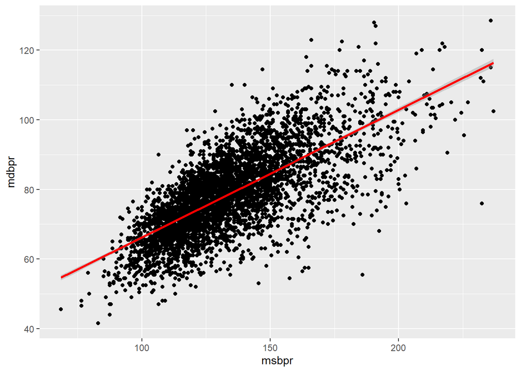

```r
data2 %>%
  ggplot(aes(msbpr, mdbpr)) + geom_point() +
   stat_smooth(method = "lm", col = "red")
```

Model with sbp (model 1)

```r
mod.sbp <- lm(hba1c ~ msbpr , data = data2)
mod.sbp.res <- tidy(mod.sbp)
mod.sbp.res
```

| term | estimate | std.error | statistic | p.value |
| --- | --- | --- | --- | --- |
| (Intercept) | 4.636496383 | 0.1263425986 | 36.697808 | 3.692585e-256 |
| msbpr | 0.008698064 | 0.0009318797 | 9.333892 | 1.605973e-20 |

Model with dbp (model 2)

```r
mod.dbp <- lm(hba1c ~ mdbpr , data = data2)
mod.dbp.res <- tidy(mod.dbp)
mod.dbp.res
```

| term | estimate | std.error | statistic | p.value |
| --- | --- | --- | --- | --- |
| (Intercept) | 4.446437 | 0.144164067 | 30.842897 | 1.446946e-188 |
| mdbpr | 0.017222 | 0.001815776 | 9.484648 | 3.941606e-21 |

Now, what happens when we add sbp and dbp (model 3)?

```r
mod.sbp.dbp <- lm(hba1c ~ msbpr + mdbpr, data = data2)
mod.sbp.dbp.res <- tidy(mod.sbp.dbp)
mod.sbp.dbp.res
```

| term | estimate | std.error | statistic | p.value |
| --- | --- | --- | --- | --- |
| (Intercept) | 4.328437719 | 0.147511836 | 29.342986 | 2.09743e-172 |
| msbpr | 0.004871894 | 0.001329822 | 3.663568 | 2.51778e-04 |
| mdbpr | 0.010435777 | 0.002592024 | 4.026111 | 5.77019e-05 |

Difference in beta between model 1 and model 3, between model 2 and model 3

1. for msbp

   | estimate |
   | --- |
   | -43.98875 |

Which model is more valid?

### Identifying Interaction

#### Numerical and numerical covariates

For example, a model with no interaction between fbs and bmi

```r
mod.fbs.bmi <- lm(hba1c ~ fbs + bmi, data = data2)
tidy(mod.fbs.bmi)
```

| term | estimate | std.error | statistic | p.value |
| --- | --- | --- | --- | --- |
| (Intercept) | 3.08492172 | 0.086669798 | 35.593965 | 1.747669e-241 |
| fbs | 0.38775409 | 0.006557742 | 59.129204 | 0.000000e+00 |
| bmi | 0.01992019 | 0.003150224 | 6.323418 | 2.837649e-10 |

For example, a model with an interaction between fbs and bmi

```r
int.fbs.bmi <- lm(hba1c ~ fbs + bmi + fbs:bmi, data = data2)
tidy(int.fbs.bmi)
```

| term | estimate | std.error | statistic | p.value |
| --- | --- | --- | --- | --- |
| (Intercept) | 3.640930894 | 0.205722094 | 17.6982979 | 1.480871e-67 |
| fbs | 0.290015974 | 0.033451665 | 8.6697022 | 6.185475e-18 |
| bmi | -0.001186750 | 0.007751733 | -0.1530947 | 8.783312e-01 |
| fbs:bmi | 0.003664537 | 0.001229930 | 2.9794689 | 2.904753e-03 |

Let’s compare between the two models and see if adding an interaction will significantly improve the model.

```r
anova(int.fbs.bmi, mod.fbs.bmi)
```

|  | Res.Df | RSS | Df | Sum of Sq | F | Pr(>F) |
| --- | --- | --- | --- | --- | --- | --- |
| 1 | 4022 | 4366.748 | NA | NA | NA | NA |
| 2 | 4023 | 4376.386 | -1 | -9.638153 | 8.877235 | 0.002904753 |

#### Numerical and categorical covariate

A model with covariates fbs and overweight

```r
mod.fbs.ow <- lm(hba1c ~ fbs + overweight, data = data2)
tidy(mod.fbs.ow)
```

| term | estimate | std.error | statistic | p.value |
| --- | --- | --- | --- | --- |
| (Intercept) | 3.4979090 | 0.042812337 | 81.703294 | 0.000000e+00 |
| fbs | 0.3895417 | 0.006545556 | 59.512397 | 0.000000e+00 |
| overweightoverwt | 0.1775251 | 0.033201513 | 5.346898 | 9.444314e-08 |

A model with covariates fbs and overweight and interaction between them

```r
int.fbs.ow <-lm(hba1c ~ fbs + overweight + fbs:overweight, data = data2)
tidy(int.fbs.ow)
```

| term | estimate | std.error | statistic | p.value |
| --- | --- | --- | --- | --- |
| (Intercept) | 3.64905016 | 0.058130656 | 62.773249 | 0.000000e+00 |
| fbs | 0.36163036 | 0.009779787 | 36.977324 | 6.531017e-258 |
| overweightoverwt | -0.10862556 | 0.081630178 | -1.330703 | 1.833620e-01 |
| fbs:overweightoverwt | 0.05042092 | 0.013144507 | 3.835893 | 1.270266e-04 |

It is difficult to assess when you have multiple p-values. **anova** can help to see overall if there is difference between models.

```r
anova(mod.fbs.ow, int.fbs.ow)
```

|  | Res.Df | RSS | Df | Sum of Sq | F | Pr(>F) |
| --- | --- | --- | --- | --- | --- | --- |
| 1 | 4023 | 4388.696 | NA | NA | NA | NA |
| 2 | 4022 | 4372.699 | 1 | 15.99707 | 14.71407 | 0.0001270266 |

### Model assessment

Let us take model with covariates fbs, overweight, crural, the interaction between fbs and overweight, msbpr, ldl and gender as our potential final model. This is known as the **preliminary final model**

```r
prelim.final.m <- lm(hba1c ~ fbs + overweight + crural + fbs:overweight +
                       msbpr + ldl + gender, data = data2)
```

#### Diagnostics plots

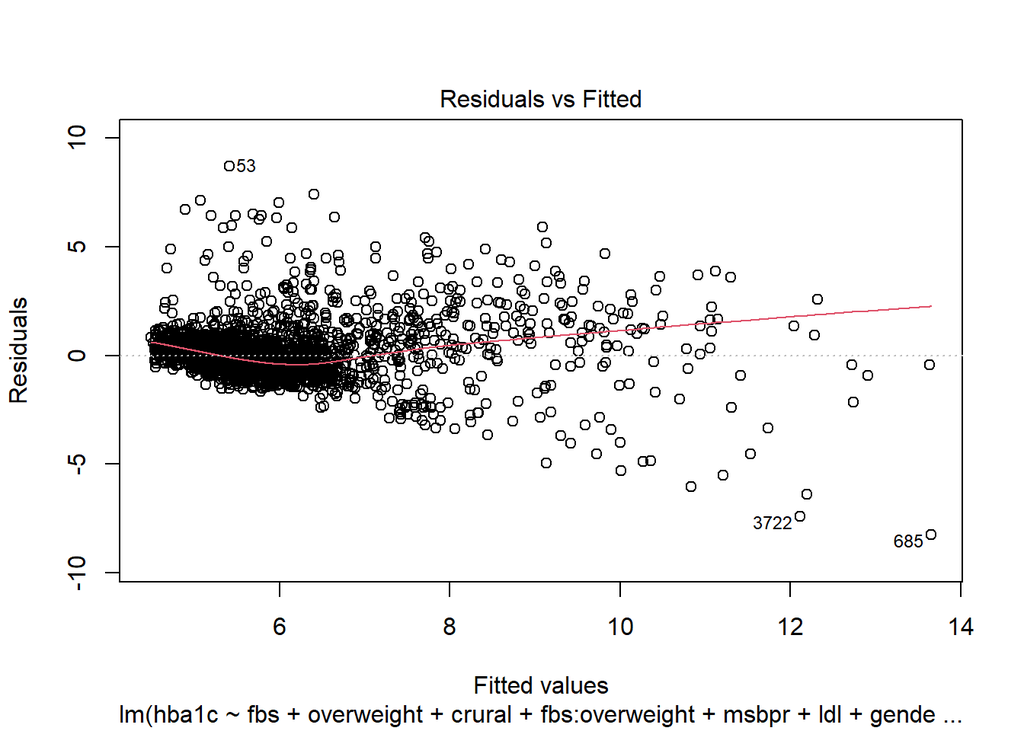

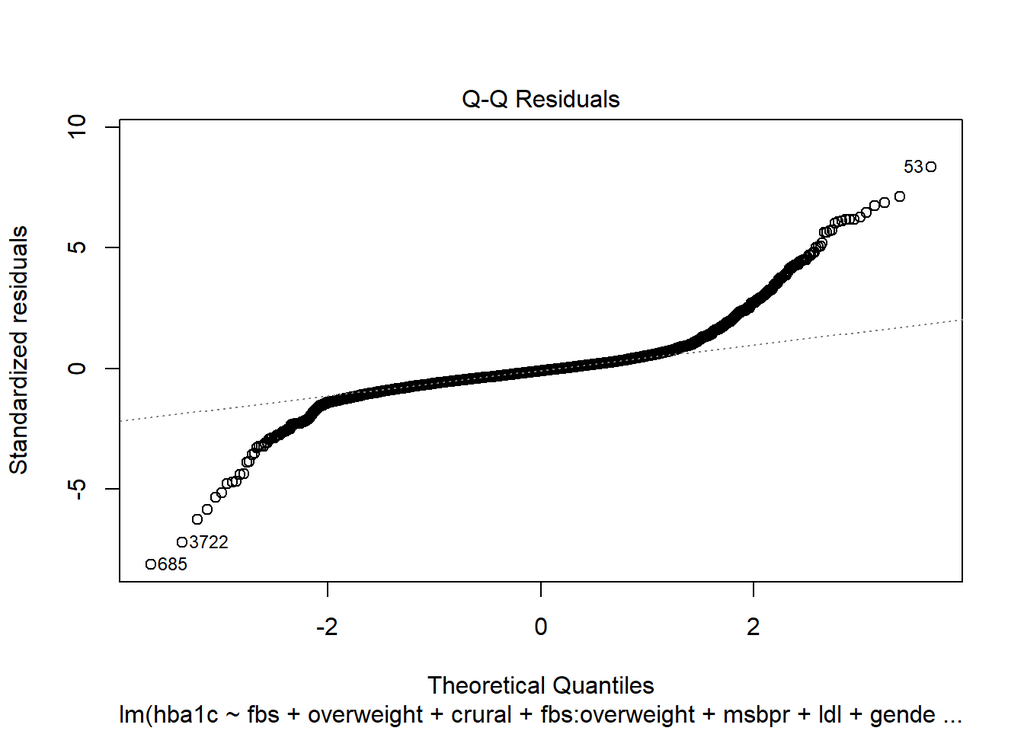

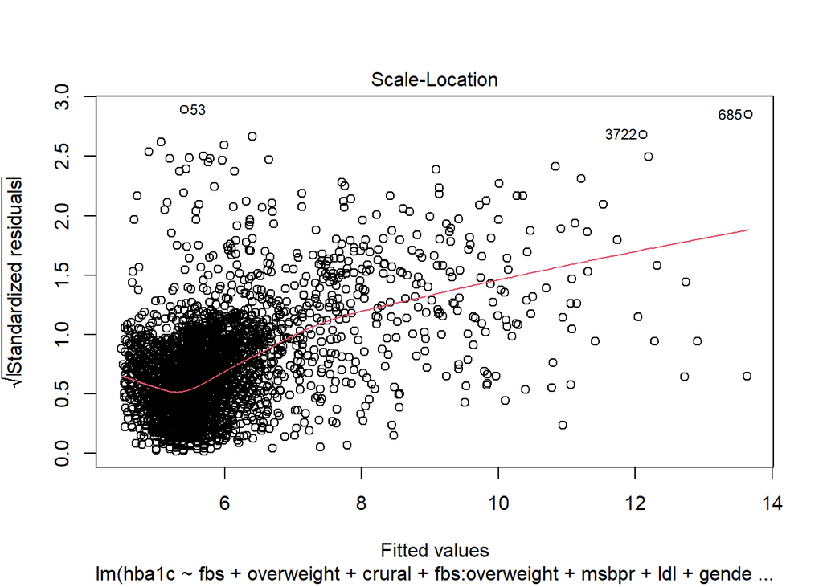

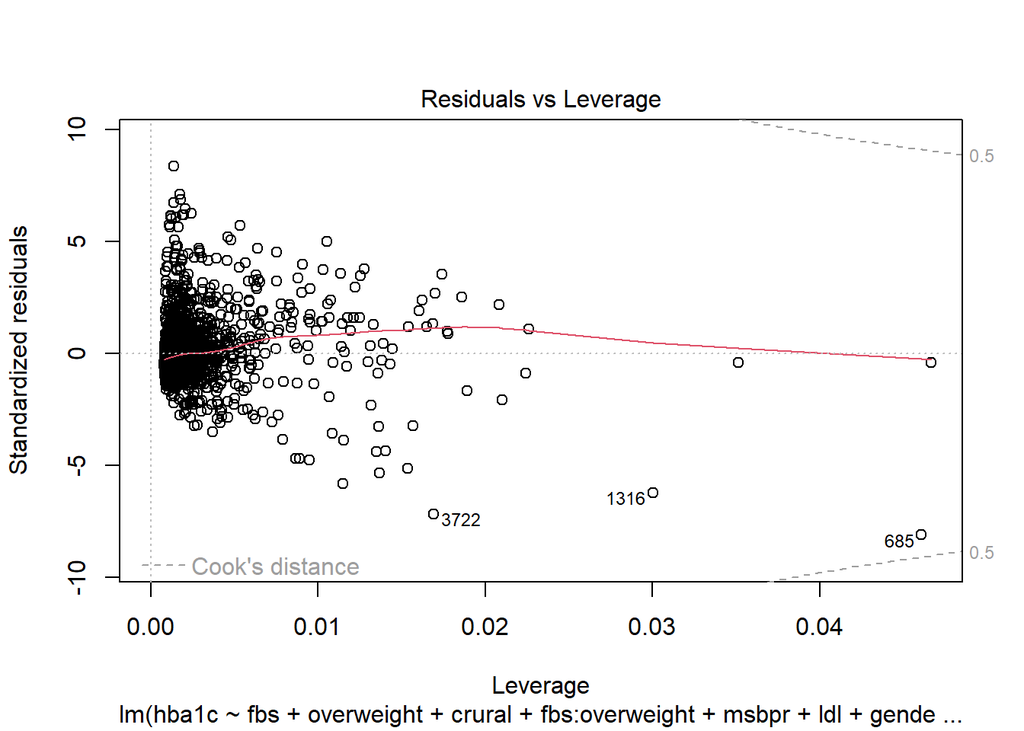

```r
plot(prelim.final.m)
```

```r
library(lmtest)
bptest(prelim.final.m)
```

```
##
##  studentized Breusch-Pagan test
##
## data:  prelim.final.m
## BP = 550.26, df = 7, p-value < 2.2e-16
```

Check the shapiro wilk test

```r
shapiro.test(prelim.final.m$residuals)
```

```
##
##  Shapiro-Wilk normality test
##
## data:  prelim.final.m$residuals
## W = 0.79781, p-value < 2.2e-16
```

Plot residuals against

- independent variables in the model
- other variables not in the model

For example

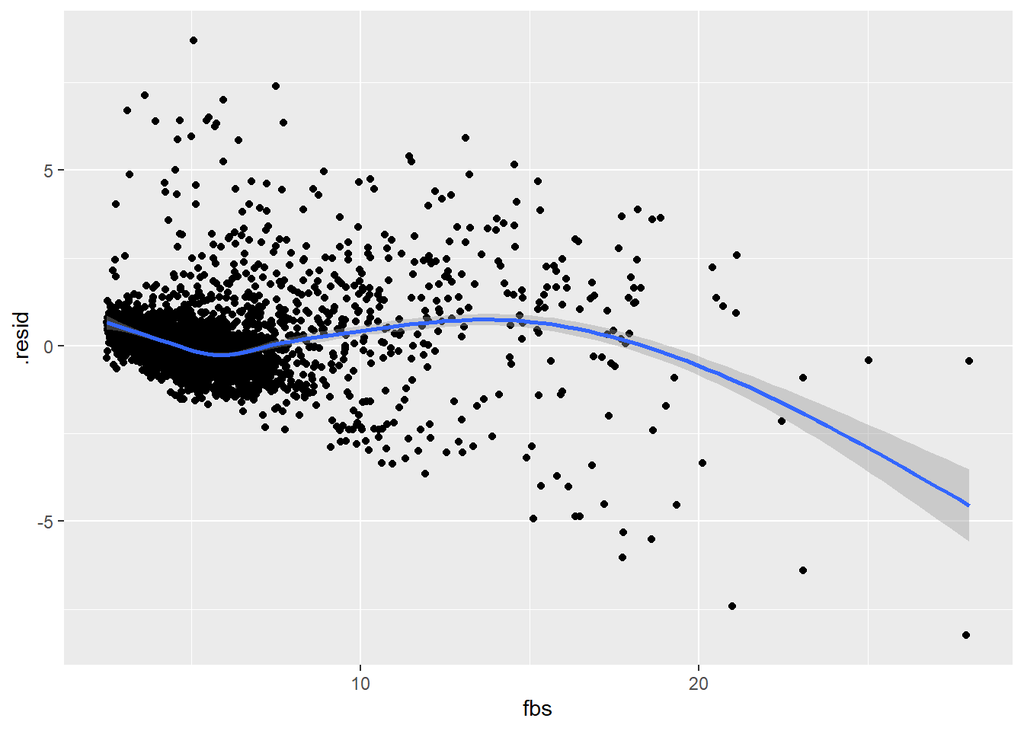

```r
augment(prelim.final.m) %>%
  ggplot(aes(x = fbs, y = .resid))+
  geom_point()+
  geom_smooth()
```

Remedial measures

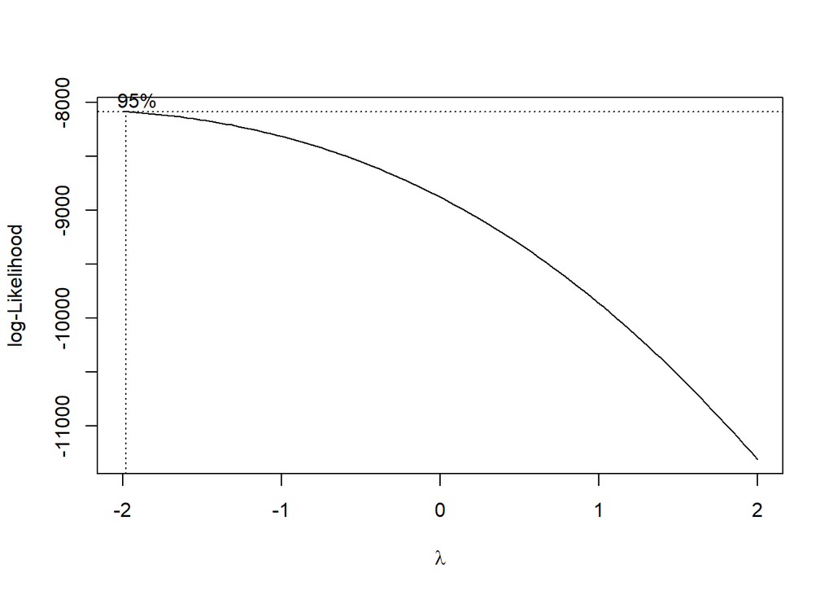

```r
MASS::boxcox(prelim.final.m)
```

#### Fitted values, residuals and influential values

Even though, R can produce automatically some plots that you can use to assess the model, it is better if you can do the plots on your own.

Steps:

1. Generate the fitted value
2. Generate the residuals
3. Generate the influential values

Based on the values above, you

- make some plots to check assumptions
- generate some diagnostic values to assess the outliers and find influential observations

```r
res.mod <- residuals(prelim.final.m)
head(res.mod)
```

```
##           1           2           3           4           5           6
##  0.12975873  0.09518729 -0.60679411 -0.46101684 -0.17402804 -0.14095941
```

Make a histogram

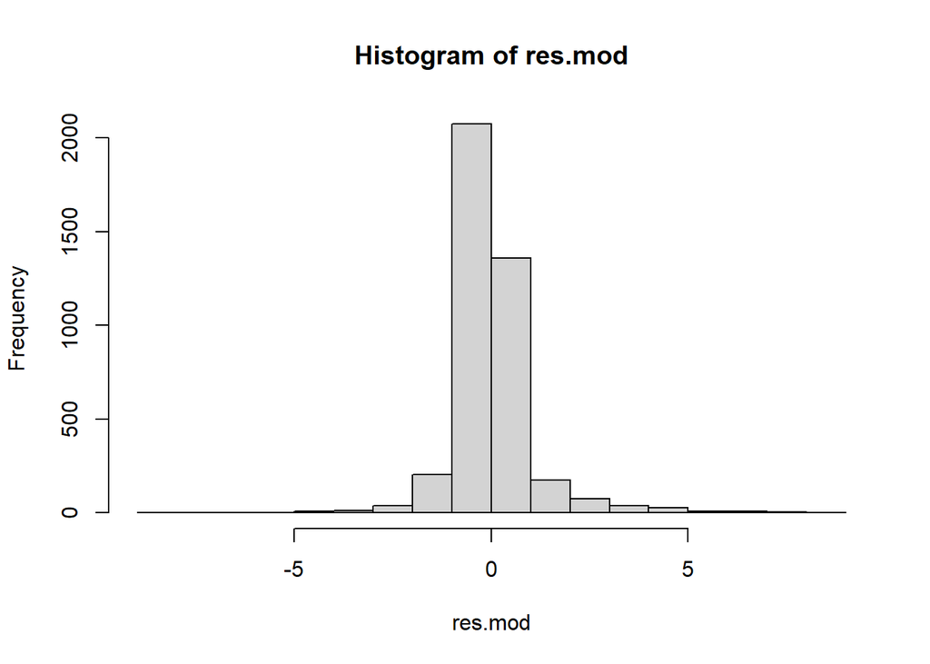

```r
hist(res.mod)
```

Alternatively, we can use `broom::augment()` to generate predictions, residuals and cluster assignments.

```r
library(DT)
```

We use `augment()` to generate the residuals values

```r
data2.pred.res <- augment(prelim.final.m)
data2.pred.res %>% datatable()
```

|  | .rownames | hba1c | fbs | overweight | crural | msbpr | ldl | gender | .fitted | .resid | .hat | .sigma | .cooksd | .std.resid |
| --- | --- | --- | --- | --- | --- | --- | --- | --- | --- | --- | --- | --- | --- | --- |
| 1 | 1 | 5.2 | 3.99 | not_overwt | rural | 135 | 2.69 | female | 5.07024127037231 | 0.1297587296276905 | 0.001266480523198299 | 1.040388490860508 | 2.469436055583614e-06 | 0.1248157645274198 |
| 2 | 2 | 5.3 | 4.26 | not_overwt | rural | 105 | 2.79 | male | 5.204812712267095 | 0.09518728773290519 | 0.001771478162410015 | 1.040389421888116 | 1.860626103767594e-06 | 0.09158442731581123 |
| 3 | 3 | 4.8 | 4.94 | not_overwt | rural | 91 | 2.55 | female | 5.406794109719326 | -0.6067941097193259 | 0.001764771292152426 | 1.040346378128925 | 7.532353774347445e-05 | -0.5838248538320373 |
| 4 | 4 | 4.8 | 4.6 | not_overwt | rural | 117 | 1.83 | male | 5.261016836286531 | -0.4610168362865315 | 0.001893881339552025 | 1.040365031653688 | 4.667219782068601e-05 | -0.4435944422294894 |
| 5 | 5 | 5.1 | 4.6 | not_overwt | rural | 102 | 2.4 | female | 5.274028041516842 | -0.1740280415168423 | 0.001503956116309737 | 1.040386878999763 | 5.277233176069227e-06 | -0.1674186083752705 |
| 6 | 6 | 5.1 | 4.42 | not_overwt | rural | 124 | 2.93 | female | 5.240959406628816 | -0.1409594066288165 | 0.00108687325705471 | 1.040388128055965 | 2.499982332765551e-06 | -0.1355775782092669 |
| 7 | 7 | 4.8 | 3.82 | not_overwt | rural | 120 | 1.82 | female | 4.955203554645373 | -0.1552035546453734 | 0.00167757362593734 | 1.040387621091858 | 4.683479396692455e-06 | -0.1493220416361517 |
| 8 | 8 | 4.9 | 4.4 | not_overwt | rural | 85 | 3.43 | female | 5.27311046336373 | -0.3731104633637301 | 0.001991485386406929 | 1.040373819367904 | 3.215206261413644e-05 | -0.3590277143640636 |
| 9 | 9 | 5.6 | 4.8 | not_overwt | rural | 112 | 3.71 | male | 5.456249270675252 | 0.143750729324748 | 0.001523991017096387 | 1.040388031789763 | 3.648821376112767e-06 | 0.1382925895097737 |
| 10 | 10 | 4.2 | 3.68 | not_overwt | rural | 108 | 2.77 | female | 4.969580018456516 | -0.7695800184565158 | 0.001441528668028502 | 1.040319546659627 | 9.890293971036899e-05 | -0.7403288981055781 |

[output cut: 4016 more lines]

### Predictions

To generate the predicted values based on current data, use the `broom::augment()` function.

If based on new data, then create new data first. To do that, we need to detach the MASS package we used before.

- Generate new data

```r
new_data <- expand.grid(fbs = c(5.0, 11.0),
                        overweight = c('overwt', 'not_overwt'),
                        crural = c('urban','rural'),
                        msbpr = mean(data2$msbpr),
                        ldl = mean(data2$ldl),
                        gender = c('female','male'))
new_data
```

| fbs | overweight | crural | msbpr | ldl | gender |
| --- | --- | --- | --- | --- | --- |
| 5 | overwt | urban | 133.5372 | 3.566587 | female |
| 11 | overwt | urban | 133.5372 | 3.566587 | female |
| 5 | not_overwt | urban | 133.5372 | 3.566587 | female |
| 11 | not_overwt | urban | 133.5372 | 3.566587 | female |
| 5 | overwt | rural | 133.5372 | 3.566587 | female |
| 11 | overwt | rural | 133.5372 | 3.566587 | female |
| 5 | not_overwt | rural | 133.5372 | 3.566587 | female |
| 11 | not_overwt | rural | 133.5372 | 3.566587 | female |
| 5 | overwt | urban | 133.5372 | 3.566587 | male |
| 11 | overwt | urban | 133.5372 | 3.566587 | male |

[output cut: 6 more lines]

Now, we can predict the average hba1c for the new data we created just now

```r
pred.hba1c <- augment(prelim.final.m, newdata = new_data)
pred.hba1c %>% datatable()
```

|  | fbs | overweight | crural | msbpr | ldl | gender | .fitted |
| --- | --- | --- | --- | --- | --- | --- | --- |
| 1 | 5 | overwt | urban | 133.5372402366864 | 3.566586982248521 | female | 5.560893464300122 |
| 2 | 11 | overwt | urban | 133.5372402366864 | 3.566586982248521 | female | 8.01414097917626 |
| 3 | 5 | not_overwt | urban | 133.5372402366864 | 3.566586982248521 | female | 5.428965889157011 |
| 4 | 11 | not_overwt | urban | 133.5372402366864 | 3.566586982248521 | female | 7.566036868614943 |
| 5 | 5 | overwt | rural | 133.5372402366864 | 3.566586982248521 | female | 5.619579854884057 |
| 6 | 11 | overwt | rural | 133.5372402366864 | 3.566586982248521 | female | 8.072827369760192 |
| 7 | 5 | not_overwt | rural | 133.5372402366864 | 3.566586982248521 | female | 5.487652279740945 |
| 8 | 11 | not_overwt | rural | 133.5372402366864 | 3.566586982248521 | female | 7.624723259198877 |
| 9 | 5 | overwt | urban | 133.5372402366864 | 3.566586982248521 | male | 5.587730941555355 |
| 10 | 11 | overwt | urban | 133.5372402366864 | 3.566586982248521 | male | 8.040978456431493 |

[output cut: 6 more lines]

### Influentials

1. Cooks distance : values above 1 or above $\frac{4}{n}$
2. standardized residuals : values above 2 or lower than $-2$
3. leverage above $\frac{2k + 2}{n}$ = $\frac{2(7) + 2}{4225} = 0.0038$

Any observation for which the Cook’s distance is close to 1 or more, or that is substantially larger than other Cook’s distances (highly influential data points), requires investigation. Good reference (here)[https://ademos.people.uic.edu/Chapter12.html#32_testing_for_outliers:_outliertest()]

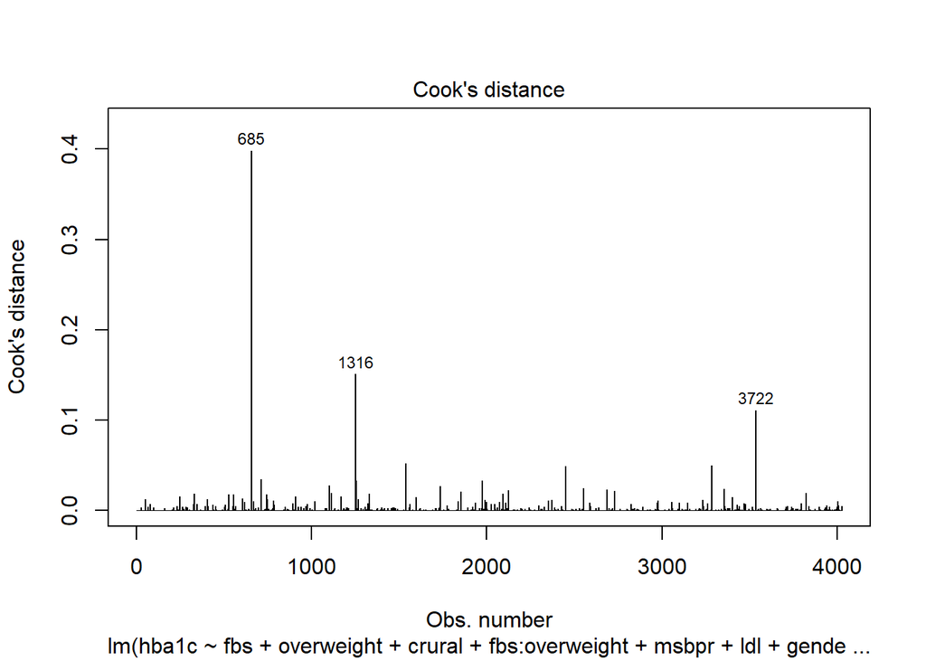

```r
cutoff <- 4/((nrow(data2)-length(prelim.final.m$coefficients)-2))
plot(prelim.final.m, which = 4, cook.levels = cutoff)
```

```r
data2.pred.res %>%
  filter(.std.resid > 2 | .std.resid < -2 | .hat > 0.0038) %>%
  datatable()
```

|  | .rownames | hba1c | fbs | overweight | crural | msbpr | ldl | gender | .fitted | .resid | .hat | .sigma | .cooksd | .std.resid |
| --- | --- | --- | --- | --- | --- | --- | --- | --- | --- | --- | --- | --- | --- | --- |
| 1 | 28 | 10.3 | 10.78 | not_overwt | rural | 134 | 3.21 | female | 7.522926214519677 | 2.777073785480324 | 0.003578796490372669 | 1.0394641109702 | 0.003211081072693353 | 2.674383029547592 |
| 2 | 53 | 14.1 | 5.06 | not_overwt | rural | 121 | 2.05 | female | 5.411765299357175 | 8.688234700642823 | 0.001383372776778399 | 1.031307367075942 | 0.01209567416080185 | 8.35775848201373 |
| 3 | 56 | 5.5 | 4.49 | not_overwt | rural | 216 | 4.1 | female | 5.32716166756474 | 0.1728383324352603 | 0.004783857903693376 | 1.040386916649194 | 1.666667376362433e-05 | 0.166547850101647 |
| 4 | 68 | 10.5 | 11.88 | not_overwt | urban | 149 | 6.05 | male | 8.066417981216652 | 2.433582018783348 | 0.005871477471351944 | 1.039677539765983 | 0.004064242913637926 | 2.346293782791449 |
| 5 | 82 | 5.2 | 13.01 | not_overwt | urban | 133.5 | 3.08 | female | 8.250084999595334 | -3.050084999595334 | 0.00626645576459457 | 1.039269884424711 | 0.006819166812652947 | -2.941268261240149 |
| 6 | 100 | 10 | 12.5 | not_overwt | rural | 140 | 1.57 | female | 8.027112013999343 | 1.972887986000657 | 0.006686128774839702 | 1.039921599397255 | 0.003046715794318983 | 1.902903860506326 |
| 7 | 171 | 5.1 | 10.65 | not_overwt | urban | 107 | 3.64 | male | 7.477457080622863 | -2.377457080622864 | 0.003996439965295217 | 1.039711338509492 | 0.002630281523550779 | -2.290023343189306 |
| 8 | 212 | 8.9 | 12.35 | not_overwt | rural | 155.5 | 0.91 | male | 7.954694453325142 | 0.9453055466748586 | 0.007632826719183855 | 1.040282770460385 | 0.000800037579715226 | 0.9122075879243022 |
| 9 | 221 | 10 | 9.64 | not_overwt | rural | 119 | 2.23 | female | 7.055189130782185 | 2.944810869217815 | 0.003108115710289028 | 1.039349255624667 | 0.003132861703281249 | 2.835247958242837 |
| 10 | 239 | 5.5 | 6.98 | not_overwt | rural | 232.5 | 3.89 | male | 6.224368199472242 | -0.7243681994722424 | 0.005928411336326935 | 1.040327355965496 | 0.0003636194533164561 | -0.6984064064587407 |

[output cut: 343 more lines]

Now let’s keep standardized residuals between 2 and -2

```r
non.influen.obs <-
  data2.pred.res %>%
  filter(.std.resid < 2 & .std.resid > -2 & .hat < 0.0038)
```

Run the model again

```r
prelim.final.m2 <- lm(hba1c ~ fbs + overweight + crural + fbs*overweight +
                       msbpr + ldl + gender, data = non.influen.obs)
```

Run diagnostics

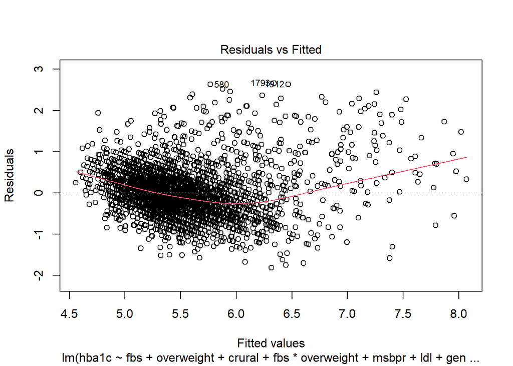

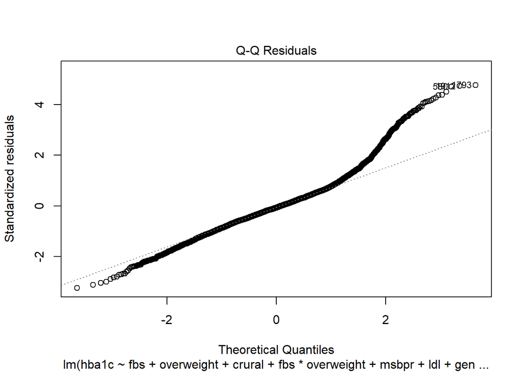

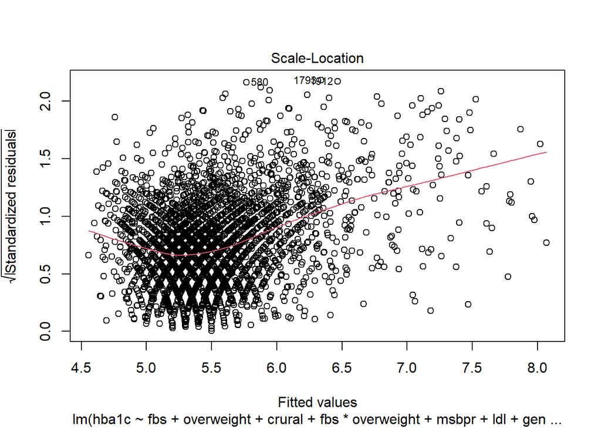

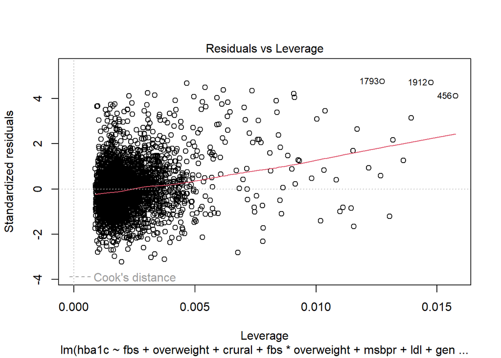

```r
plot(prelim.final.m2)
```

## Conclusion

- Model specification is important
- Which variables are
  - confounders
  - mediators
  - moderators
- Effect of multicolinearity
- Model checking and model assessment
- Are there outliers and are they influentials?
- Simple model vs complex model
- Bias and variance
- Exploratory vs Confirmatory model